# Practica 2

Brais Santos Negreira / Jorge Álvarez Gracia

Diciembre 2021

# 1 Descripción del dataset

## 1.1 Introducción

Este proyecto corresponde a la asignatura de Tipología y ciclo de vida de los datos del máster oficial de Ciencia de de datos de la Universidad Oberta de Cataluña UOC. En el pretendemos afianzar todos los conceptos estudiados en la segunda parte de la asignatura, limpieza y análisis de los datos. Para ello, en primer lugar deberemos elegir un dataset donde a través de la información recogida seamos capaces de llevar a cabo los análisis estudiados en la asignatura, así cómo obtener unas conclusiones de los análisis interesantes.

## 1.2 Elección del DataSet

Para ello y después de analizar los distintos dataset disponibles en la plataforma kaggle, hemos optado por el conjunto de datos disponible en el siguiente enlace: https://www.kaggle.com/fedesoriano/heart-failure-prediction.

## 1.3 Importancia y objetivos de los análisis

El termino cardiopatía se refiere a cualquier enfermedad del corazón independientemente de su naturaleza . Según la OMS las Enfermedades cardiovasculares (ECV) son un conjunto de trastornos al corazón y de los vasos sanguíneos, siendo la principal causa de defunción en el mundo.

Como datos llamativos:

• 17,5 millones de personas murieron por enfermedades cardiovasculares en el mundo.

• 80% de los infartos de miocardio y de los AVC prematuros son prevenibles.

• Más del 75% de las muertes causadas por ECV se producen en países de ingresos medios y bajos.

En España y como podemos leer en la web de la Sociedad Española de Cardiología (SEC): La enfermedad cardiovascular continúa siendo la primera causa de muerte en nuestro país, con 120.859 fallecimientos registrados al año, según los últimos datos del Instituto Nacional de Estadística (2018).

Si nos fijamos en el segundo punto de las afirmaciones de la OMS, el 80% de los infartos se pueden prevenir. Esto significa que con un estudio pormenorizado de los factores de riesgo, utilizando la cantidad de datos médicos existentes y modelos de machine learning, estas causas de defunción se podrían disminuir considerablemente pudiendo prever con antelación que grupos de población con sus respectivas características médicas van a tener más riesgos que otros.

En definitiva, conocer aquellas variables que más influyen en el riesgo de padecer enfermedades cardiovasculares y ser capaces de obtener modelos capaces de predecir si una persona va a sufrir una enfermedad de este tipo o no puede salvar vidas.

Por ello, podemos considerar la predicción de enfermedades cardiovasculares como uno de los objetivos más importantes de la minería de datos y del machine learning dentro de la medicina.

## 1.4 Objetivos

Como hemos comentado anteriormente, el objetivo de esta práctica es afianzar los conceptos teóricos vistos en la asignatura a la vez que obtenemos información relevante y análisis de aquellas variables que afectan al riesgo de padecer enfermedades cardíacas.

# 2 Integración y selección de los datos de interés a analizar

## 2.1 Carga del dataset

Se lee el fichero “heart.csv”.

```r
heart <- read.csv("heart.csv",sep=",")
```

## 2.2 Explicación de las variables

A continuación, obtenemos el listado de variables:

```r
str(heart)
```

```
## 'data.frame':    918 obs. of  12 variables:
##  $ Age           : int  40 49 37 48 54 39 45 54 37 48 ...
##  $ Sex           : chr  "M" "F" "M" "F" ...
##  $ ChestPainType : chr  "ATA" "NAP" "ATA" "ASY" ...
##  $ RestingBP     : int  140 160 130 138 150 120 130 110 140 120 ...
##  $ Cholesterol   : int  289 180 283 214 195 339 237 208 207 284 ...
##  $ FastingBS     : int  0 0 0 0 0 0 0 0 0 0 ...
##  $ RestingECG    : chr  "Normal" "Normal" "ST" "Normal" ...
##  $ MaxHR         : int  172 156 98 108 122 170 170 142 130 120 ...
##  $ ExerciseAngina: chr  "N" "N" "N" "Y" ...
##  $ Oldpeak       : num  0 1 0 1.5 0 0 0 0 1.5 0 ...
##  $ ST_Slope      : chr  "Up" "Flat" "Up" "Flat" ...
##  $ HeartDisease  : int  0 1 0 1 0 0 0 0 1 0 ...
```

**Age** : edad del paciente.

**Sex** : sexo del paciente.

**ChestPainType** : Tipo de dolor del pecho.

**RestingBP** : presión arterial en reposo (sistólica).

**Cholesterol** : colesterol sérico.

**FastingBS** : azúcar en sangre en ayunas.

**RestingECG**: resultados del electrocardiograma en reposo.

**MaxHR**: frecuencia cardíaca máxima alcanzada.

**ExerciseAngina**: angina inducida por el ejercicio.

**Oldpeak** : ejercicio inducido por la depresión (ST) en relación con el descanso.

**ST_Slope** : pendiente del segmento ST del ejercicio pico.

**HeartDisease** : clase de salida.

Vamos a realizar una explicación más extensa de cada variable según los criterios médicos para conocer estos conceptos y su influencia respecto a la hora de sufrir una enfermedad cardíaca.

**Age** : La edad es el factor de riesgo más importante en el desarrollo de enfermedades cardiovasculares o cardíacas, según la SEC, con aproximadamente un triple de riesgo con cada década de vida. Las vetas de grasa coronarias pueden comenzar a formarse en la adolescencia. Se estima que el 82 por ciento de las personas que mueren de enfermedad coronaria tienen 65 años o más. Simultáneamente, el riesgo de accidente cerebrovascular se duplica cada década después de los 55 años.

**Sex**: Los hombres tienen un mayor riesgo de enfermedad cardíaca que las mujeres premenopáusicas. Una vez pasada la menopausia, se ha argumentado que el riesgo de una mujer es similar al del hombre, aunque datos más recientes de la OMS y la ONU lo niegan. Si una mujer tiene diabetes, tiene más probabilidades de desarrollar una enfermedad cardíaca que un hombre con diabetes.

**ChestPainType**: la angina o dolor de pecho es un malestar que se produce cuando el músculo cardíaco no recibe suficiente sangre rica en oxígeno.

**RestingBP**: la presión arterial alta puede dañar las arterias que alimentan el corazón. La presión arterial alta puede ocurrir debido a distintas afecciones, como la obesidad, el colesterol alto o la diabetes.

**Cholesterol**: Un nivel alto de colesterol unido a lipoproteínas de baja densidad (LDL) (el colesterol “malo”) ayuda a que las arterias se estrechen. Un nivel alto de triglicéridos, un tipo de grasa en la sangre, también aumenta el riesgo de un ataque cardíaco. Sin embargo, un nivel alto de colesterol de lipoproteínas de alta densidad (HDL) (el colesterol “bueno”) reduce el riesgo de sufrir un ataque cardíaco.

**FastingBS**: No producir suficiente hormona secretada por el páncreas (insulina) o no responder a la insulina de manera adecuada hace que los niveles de azúcar en sangre del cuerpo aumenten, lo que aumenta el riesgo de un ataque cardíaco.

**RestingECG**: Para las personas con bajo riesgo de enfermedad cardiovascular, la USPSTF concluye con certeza moderada que los daños potenciales de la detección con ECG en reposo o de ejercicio igualan o superan los beneficios potenciales. Para las personas con riesgo intermedio a alto, la evidencia actual es insuficiente para evaluar el balance de beneficios y daños del cribado.

**MaxHR**: Se ha demostrado que un aumento de la frecuencia cardíaca de 10 latidos por minuto se asoció con un aumento del riesgo de muerte cardíaca en al menos un 20%.

**ExerciseAngina**: Angina inducida por una actividad física.

**Oldpeak**: el infarto de miocardio con elevación del segmento ST es una emergencia médica producida por la formación de un trombo sobre una placa rota de aterosclerosis que ocluye la circulación coronaria del músculo cardíaco.

**ST_Slope**: pendiente del segmento ST.

Se muestra un resumen de las variables.

```r
summary(heart)
```

```
##       Age            Sex            ChestPainType        RestingBP
##  Min.   :28.00   Length:918         Length:918         Min.   :  0.0
##  1st Qu.:47.00   Class :character   Class :character   1st Qu.:120.0
##  Median :54.00   Mode  :character   Mode  :character   Median :130.0
##  Mean   :53.51                                         Mean   :132.4
##  3rd Qu.:60.00                                         3rd Qu.:140.0
##  Max.   :77.00                                         Max.   :200.0
##   Cholesterol      FastingBS       RestingECG            MaxHR
##  Min.   :  0.0   Min.   :0.0000   Length:918         Min.   : 60.0
##  1st Qu.:173.2   1st Qu.:0.0000   Class :character   1st Qu.:120.0
##  Median :223.0   Median :0.0000   Mode  :character   Median :138.0
##  Mean   :198.8   Mean   :0.2331                      Mean   :136.8
##  3rd Qu.:267.0   3rd Qu.:0.0000                      3rd Qu.:156.0
##  Max.   :603.0   Max.   :1.0000                      Max.   :202.0
##  ExerciseAngina        Oldpeak          ST_Slope          HeartDisease
##  Length:918         Min.   :-2.6000   Length:918         Min.   :0.0000
##  Class :character   1st Qu.: 0.0000   Class :character   1st Qu.:0.0000
##  Mode  :character   Median : 0.6000   Mode  :character   Median :1.0000
##                     Mean   : 0.8874                      Mean   :0.5534
##                     3rd Qu.: 1.5000                      3rd Qu.:1.0000
##                     Max.   : 6.2000                      Max.   :1.0000
```

A partir de esto, se puede concluir con que hay 12 variables y 918 observaciones. También se aprecia que en el dataset hay 3 tipos de datos:

Variables numéricas: Oldpeak.

Variables de tipo carácter: Sex, ChestPainType, RestingECG, ExerciseAngina, ST_Slope.

Variables de tipo entero: Age, RestingBP, Cholesterol, FastingBS, MaxHR, HeartDisease.

# 3 Limpieza y preprocesado de datos

## 3.1 Conversión y estandarización

Pasamos los valores int a numeric y los char a factor.

```r
heart$Age <- as.numeric(heart$Age)
heart$Sex <- as.factor(heart$Sex)
heart$ChestPainType <- as.factor(heart$ChestPainType)
heart$RestingBP <- as.numeric(heart$RestingBP)
heart$Cholesterol <- as.numeric(heart$Cholesterol)
heart$FastingBS <- as.numeric(heart$FastingBS)
heart$RestingECG  <- as.factor(heart$RestingECG)
heart$MaxHR <- as.numeric(heart$MaxHR)
heart$ExerciseAngina <- as.factor(heart$ExerciseAngina)
heart$ST_Slope <- as.factor(heart$ST_Slope)
heart$HeartDisease <- as.numeric(heart$HeartDisease)
```

## 3.2 Estudio de outliers

En este apartado, se va a mostrar el diagrama de cajas de cada una de las variables numéricas para comprobar si hay posibles outliers.

**Age**:

Se aprecia que en la variable “Age” no hay ningún valor extremo.

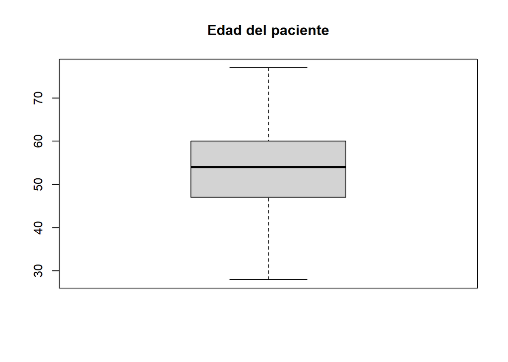

```r
boxplot(heart$Age,main="Edad del paciente")
```

```r
boxplot.stats(heart$Age)$out
```

```
## numeric(0)
```

**RestingBP**:

En el campo “RestingBP” se observa algunos outliers, pero no se eliminarán debido a que la presión arterial sistólica puede tener valores superiores a 180 (esto sería una crisis de hipertensión).

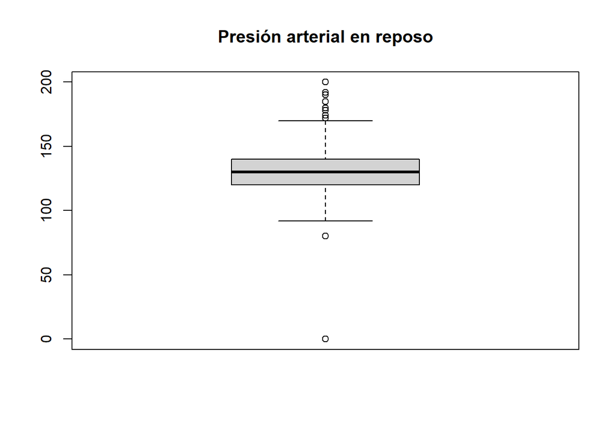

```r
boxplot(heart$RestingBP,main="Presión arterial en reposo")
```

```r
boxplot.stats(heart$RestingBP)$out
```

```
##  [1] 190 180 180 180 200 180 180 180  80 200 185 200 180 180   0 178 172 180 190
## [20] 174 178 180 200 192 178 180 180 172
```

**Cholesterol**:

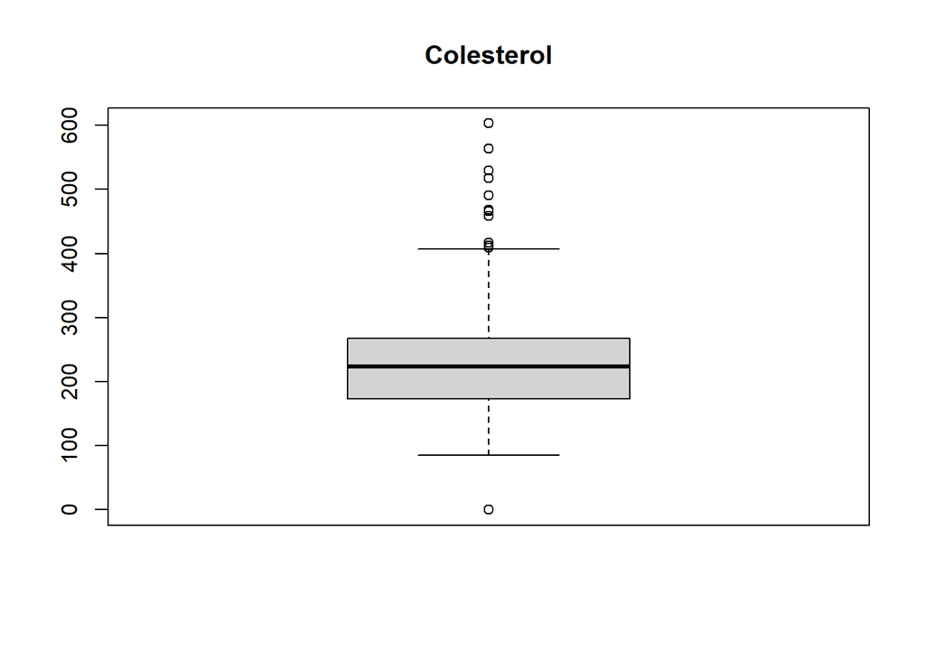

```r
boxplot(heart$Cholesterol,main="Colesterol")
```

```r
boxplot.stats(heart$Cholesterol)$out
```

```
##   [1] 468 518 412 529 466 603 491   0   0   0   0   0   0   0   0   0   0   0
##  [19]   0   0   0   0   0   0   0   0   0   0   0   0   0   0   0   0   0   0
##  [37]   0   0   0   0   0   0   0   0   0   0   0   0   0   0   0   0   0   0
##  [55]   0   0   0   0   0   0   0   0   0   0   0   0   0   0   0   0   0   0
##  [73]   0   0   0   0   0   0   0   0   0   0   0   0   0   0   0   0   0   0
##  [91]   0   0   0   0   0   0   0   0   0   0   0   0   0   0   0   0   0   0
## [109]   0   0   0   0   0   0   0   0   0   0   0   0   0   0   0   0   0   0
## [127]   0   0   0   0   0   0   0   0   0   0   0   0   0   0   0   0   0   0
## [145]   0   0   0   0   0   0   0   0   0   0   0   0   0   0   0   0   0   0
## [163]   0   0   0   0   0   0   0   0   0   0   0 458   0   0   0   0   0   0
## [181] 564 417 409
```

**MaxHR** :

Se puede apreciar que hay dos valores extremos: 60 y 63. Esas frecuencias cardíacas **máximas** son muy bajas y por tanto lo podemos detectar como valores extraños.

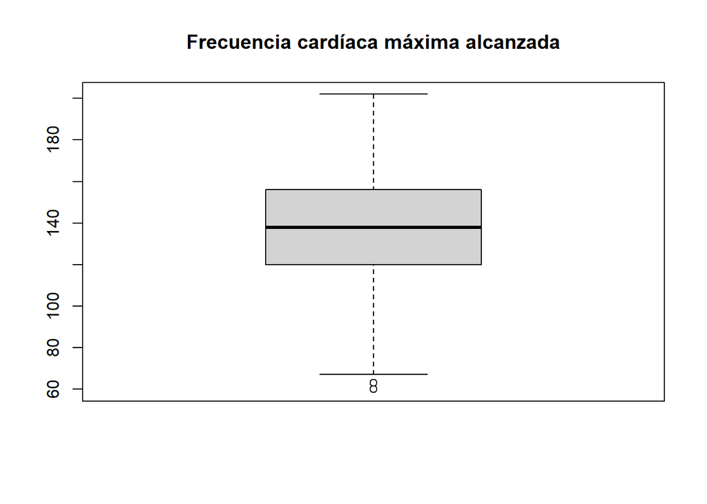

```r
boxplot(heart$MaxHR,main="Frecuencia cardíaca máxima alcanzada")
```

```r
boxplot.stats(heart$MaxHR)$out
```

```
## [1] 63 60
```

A continuación, sustituimos esos valores por NA y luego lo trataremos mediante Knn.

```r
posMaxHR <- which(heart$MaxHR==60 | heart$MaxHR==63)


heart$MaxHR[posMaxHR] <- NA
```

Se aplica kNN para ponerle un valor en función de sus vecinos más cercanos.

```r
library(VIM)
MaxHR_new <- kNN(heart,variable="MaxHR",dist_var =c("Age","Sex","ChestPainType","FastingBS","RestingECG","ExerciseAngina","ST_Slope","HeartDisease"),k=3)
MaxHR_new <- MaxHR_new$MaxHR

heart$MaxHR <- MaxHR_new
```

Se comprueba que en esa posición hay otro valor diferente.

```r
heart$MaxHR[posMaxHR]
```

```
## [1] 144 150
```

## 3.3 Estudio de Valores nulos

Se aprecia que no hay ningún valor NA.

```r
colSums(is.na(heart))
```

```
##            Age            Sex  ChestPainType      RestingBP    Cholesterol
##              0              0              0              0              0
##      FastingBS     RestingECG          MaxHR ExerciseAngina        Oldpeak
##              0              0              0              0              0
##       ST_Slope   HeartDisease
##              0              0
```

A continuación, comprobaremos si algún campo tiene un valor 0.

```r
colSums(heart == 0)
```

```
##            Age            Sex  ChestPainType      RestingBP    Cholesterol
##              0              0              0              1            172
##      FastingBS     RestingECG          MaxHR ExerciseAngina        Oldpeak
##            704              0              0              0            368
##       ST_Slope   HeartDisease
##              0            410
```

Viendo esto, se puede decir que no tiene sentido que los campos RestingBP y Cholesterol tengan ceros. En este caso, podemos hablar de información perdida.

```r
posRestingBP <- which(heart$RestingBP == 0)

posCholesterol <- which(heart$Cholesterol == 0)

heart$RestingBP[posRestingBP] <- NA

heart$Cholesterol[posCholesterol] <- NA
```

Para esos 0, hemos metido NA ya que es un valor desconocido y ahora miraremos mediante Knn como tratar esos datos.

Para solucionar estos valores perdidos, vamos a hacer uso de la función knn.

```r
RestingBP_new <- kNN(heart,variable="RestingBP",dist_var =c("Age","Sex","ChestPainType","FastingBS","RestingECG","ExerciseAngina","ST_Slope","HeartDisease"),k=3)
RestingBP_new <- RestingBP_new$RestingBP

heart$RestingBP <- RestingBP_new

Cholesterol_new <- kNN(heart,variable="Cholesterol",dist_var =c("Age","Sex","ChestPainType","FastingBS","RestingECG","ExerciseAngina","ST_Slope","HeartDisease"),k=3)
Cholesterol_new <- Cholesterol_new$Cholesterol

heart$Cholesterol <- Cholesterol_new
```

Se comprueba que ya no hay valores perdidos en esas posiciones:

```r
heart$RestingBP[posRestingBP]
```

```
## [1] 135
```

```r
heart$Cholesterol[posCholesterol]
```

```
##   [1] 235 270 230 204 277 254 223 203 182 230 288 254 230 254 182 230 210 177
##  [19] 230 223 223 217 267 218 230 203 254 218 203 294 210 203 237 192 203 204
##  [37] 258 212 223 292 223 230 282 240 203 258 210 263 210 203 254 254 237 198
##  [55] 254 219 237 254 228 223 230 228 282 231 267 193 233 309 226 228 230 231
##  [73] 269 260 171 274 297 253 235 253 216 233 211 193 203 263 228 281 233 247
##  [91] 282 216 260 315 266 224 203 206 219 254 237 213 254 272 277 230 220 263
## [109] 203 203 204 193 237 213 263 203 256 203 254 282 218 204 254 203 219 254
## [127] 281 297 254 277 220 220 212 203 219 213 203 203 277 285 233 237 252 207
## [145] 213 309 254 203 240 297 179 233 228 302 216 235 277 283 249 241 228 213
## [163] 211 226 235 291 210 223 211 245 276 245
```

Observamos que los valores NA fueron sustituidos por otros en función de las características de los demás atributos.

Finalmente, vemos que ya no hay ningún valor perdido.

```r
colSums(is.na(heart))
```

```
##            Age            Sex  ChestPainType      RestingBP    Cholesterol
##              0              0              0              0              0
##      FastingBS     RestingECG          MaxHR ExerciseAngina        Oldpeak
##              0              0              0              0              0
##       ST_Slope   HeartDisease
##              0              0
```

## 3.4 PCA: Análisis de componentes principales

Con el PCA lo que se busca es reducir la dimensionalidad. Partimos de una serie de atributos numéricos del dataset “heart.csv” correlacionados y eso lo convertiremos en menos variables sin estar relacionadas entre si, pero queriendo mantener la mayor información posible.

En el dataset “heart.csv”, no todos los atributos son numéricos. Por tanto, los convertiremos y lo añadiremos en otro dataset.

```r
heart_num <- heart
heart_num$Sex <- with(heart_num, ifelse(Sex == "M", 0,1))
heart_num$ChestPainType <- with(heart_num, ifelse(ChestPainType == "ASY",0,ifelse(ChestPainType == "ATA",1,ifelse(ChestPainType == "NAP",2,3))))
heart_num$RestingECG <- with(heart_num, ifelse(RestingECG == "LVH",0,ifelse(RestingECG == "Normal",1,2)))
heart_num$ExerciseAngina <- with(heart_num, ifelse(ExerciseAngina == "N", 0,1))
heart_num$ST_Slope <- with(heart_num, ifelse(ST_Slope == "Down", 0,ifelse(ST_Slope == "Flat",1,2)))
```

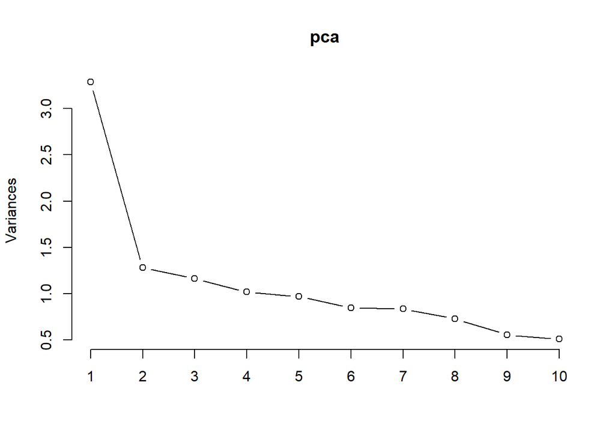

```r
 pca = prcomp(heart_num, scale = TRUE)

  plot(pca, type="l")
```

En la gráfica se observa cuales son los componentes principales más significativos o con más “peso”. Estos son el PC1 y PC2.

Se muestra un resumen de cada uno de los componentes principales.

```r
summary(pca)
```

```
## Importance of components:
##                           PC1    PC2     PC3     PC4    PC5     PC6     PC7
## Standard deviation     1.8126 1.1324 1.07801 1.00941 0.9847 0.92187 0.91485
## Proportion of Variance 0.2738 0.1069 0.09684 0.08491 0.0808 0.07082 0.06975
## Cumulative Proportion  0.2738 0.3807 0.47751 0.56242 0.6432 0.71404 0.78378
##                            PC8     PC9    PC10    PC11    PC12
## Standard deviation     0.85462 0.74550 0.71506 0.65864 0.60277
## Proportion of Variance 0.06087 0.04631 0.04261 0.03615 0.03028
## Cumulative Proportion  0.84465 0.89096 0.93357 0.96972 1.00000
```

Visto la información que da “Proportion of Variance”, el PC1 y PC2 nos dá el 38.07% de la información del dataset.

La línea roja indica el valor medio de contribución. Podemos decir que aquellas variables superiores a esta linea son importantes a la hora de contribuir a este componente.

```r
library("factoextra")
```

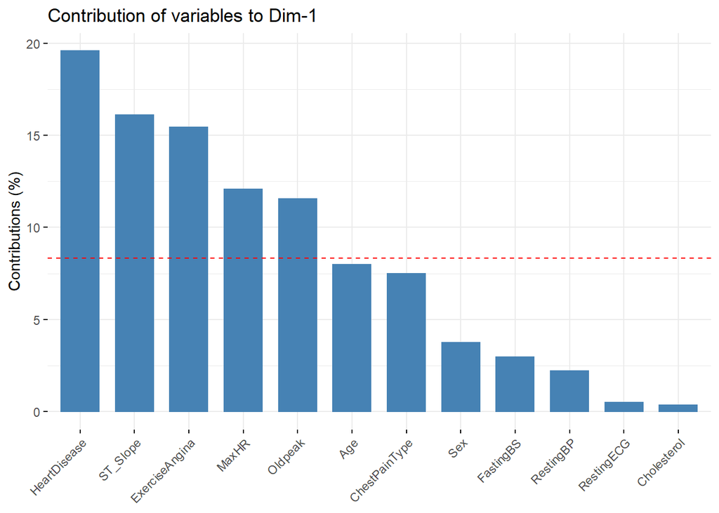

```r
fviz_contrib(pca, addlabels = TRUE, choice = "var", axes = 1, top = 20)
```

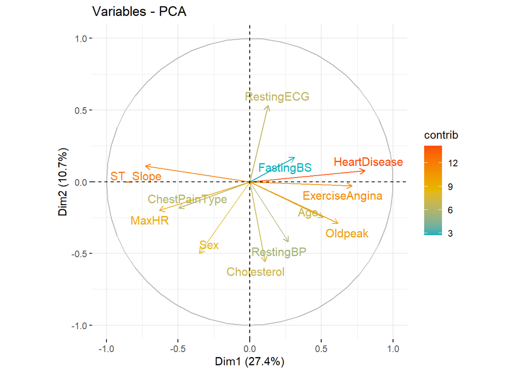

```r
library("factoextra")

fviz_pca_var(pca,
             col.var = "contrib", # color en funcón de la contribución.
             gradient.cols = c("#00AFBB", "#E7B800", "#FC4E07"),
             repel = TRUE
             )
```

Viendo esto, se puede ver como el PC1 le asigna más peso a la variable “HeartDisease” que se mueve por el eje X. Por otro lado, vemos como el PC2 le asigna más peso a la variable “RestingECG” que se mueve por el eje Y.

Se muestra otro gráfico para que la información quede más clara.

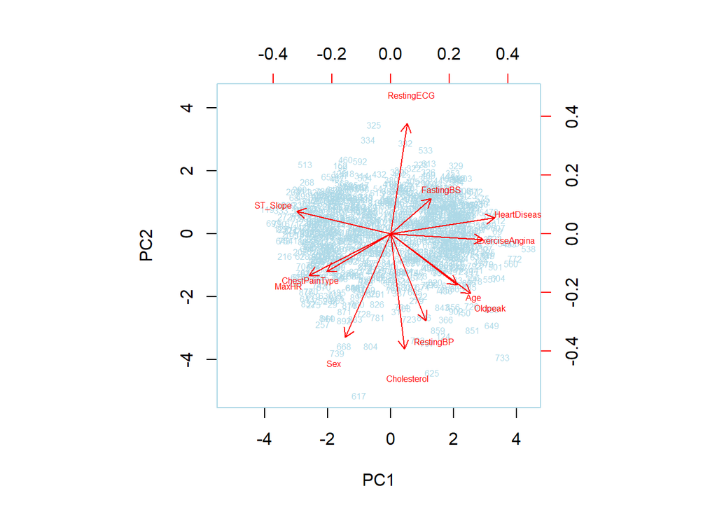

```r
biplot(pca, scale = 0, cex = 0.5, col = c("lightblue", "red"))
```

Se aprecia como la información es bastante dispar entre los diferentes componentes PC1 y PC2. Por lo tanto, decidimos no eliminar ningún campo del dataset ya que podemos considerar que todas las variables son importantes.

## 3.5 Normalización

En este apartado, lo que vamos a hacer es normalizar el campo Age usando min-max. Se creará un nuevo campo llamado Age_nor y se añadirá al dataset.

```r
Age_nor <- (2*(heart$Age-min(heart$Age))/(max(heart$Age)-min(heart$Age)))-1
heart <- cbind(heart,Age_nor)
```

Estos datos, están en el intervalo [-1,1]

```r
min(heart$Age_nor)
```

```
## [1] -1
```

```r
max(heart$Age_nor)
```

```
## [1] 1
```

Se normaliza esta variable para acotar los datos en un intervalo más pequeño ya que puede haber edades dispares y también para poder ver si esta variable puede llegar a seguir una distribución normal.

## 3.6 Discretización de variables

En esta apartado, también usaremos la variable “Age” para discretizarla en diferentes rangos y se añadirá al dataset con el nombre Age_dis.

```r
Age_dist <- cut(heart$Age, breaks = c(0,40,60,80), labels = c("(0-40]","(40,60]","(60,80]"))

heart <- cbind(heart,Age_dist)
```

Se discretiza esta variable para dividir la edad en rangos y poder realizar los análisis gráficos más eficientemente, y de esta manera comprobar como influirá cada variable a la hora de sufrir una enfermedad cardíaca según los diferentes grupos de edad de la población.

# 4 Análisis de los datos

## 4.1 Estudio descriptivo de las variables

Ahora, tenemos el dataset sin valores vacíos así como con las nuevas variables normalizadas y discretizadas.

Por lo tanto, se muestra un resumen del dataset en el cual podemos ver la media, moda, cuartiles y valores mínimos y máximos en el caso de variables numéricas.

Obtenemos las distintas medidas para las variables cuantitativas:

```r
id = c(1,4,5,6,8,10)
mean <- as.vector(sapply(heart[,id],mean,na.rm = TRUE))
std <- as.vector(sapply(heart[,id],sd,na.rm = TRUE))
median <- as.vector(sapply(heart[,id],median,na.rm = TRUE))
mean.trim <- as.vector(sapply(heart[,id],mean,na.rm = TRUE,trim = 0.05))
IQR <- as.vector(sapply(heart[,id],IQR,na.rm = TRUE))
mad <- as.vector(sapply(heart[,id],mad,na.rm = TRUE))
```

Creamos dos tablas con las medidas obtenidas anteriormente:

```r
library(kableExtra)
kable(data.frame(Variables = names(heart)[id],MEDIA   = mean, MEDIANA   = median, MEDIA_RECORTADA  = mean.trim),
digits = 3, caption = "Estimaciones tendencia central")%>% kable_styling(bootstrap_options = c("striped","hover", "responsive"),position = "left")
```

Estimaciones tendencia central

| Variables | MEDIA | MEDIANA | MEDIA_RECORTADA |
| --- | --- | --- | --- |
| Age | 53.511 | 54.0 | 53.589 |
| RestingBP | 132.544 | 130.0 | 131.899 |
| Cholesterol | 243.002 | 235.0 | 240.302 |
| FastingBS | 0.233 | 0.0 | 0.204 |
| MaxHR | 136.996 | 138.0 | 137.258 |
| Oldpeak | 0.887 | 0.6 | 0.805 |

```r
kable(data.frame(Variables = names(heart)[id],SD = std, IQR = IQR, MAD = mad),
digits = 3, caption = "Estimaciones de dispersión")%>% kable_styling(bootstrap_options = c("striped","hover", "responsive"),position = "left")
```

Estimaciones de dispersión

| Variables | SD | IQR | MAD |
| --- | --- | --- | --- |
| Age | 9.433 | 13.0 | 10.378 |
| RestingBP | 17.990 | 20.0 | 14.826 |
| Cholesterol | 55.018 | 63.0 | 45.961 |
| FastingBS | 0.423 | 0.0 | 0.000 |
| MaxHR | 25.220 | 36.0 | 26.687 |
| Oldpeak | 1.067 | 1.5 | 0.890 |

En el caso de los factores, podemos ver el número de ocurrencias que tiene dicho valor.

```r
summary(heart)
```

```
##       Age        Sex     ChestPainType   RestingBP      Cholesterol
##  Min.   :28.00   F:193   ASY:496       Min.   : 80.0   Min.   : 85
##  1st Qu.:47.00   M:725   ATA:173       1st Qu.:120.0   1st Qu.:209
##  Median :54.00           NAP:203       Median :130.0   Median :235
##  Mean   :53.51           TA : 46       Mean   :132.5   Mean   :243
##  3rd Qu.:60.00                         3rd Qu.:140.0   3rd Qu.:272
##  Max.   :77.00                         Max.   :200.0   Max.   :603
##    FastingBS       RestingECG      MaxHR     ExerciseAngina    Oldpeak
##  Min.   :0.0000   LVH   :188   Min.   : 67   N:547          Min.   :-2.6000
##  1st Qu.:0.0000   Normal:552   1st Qu.:120   Y:371          1st Qu.: 0.0000
##  Median :0.0000   ST    :178   Median :138                  Median : 0.6000
##  Mean   :0.2331                Mean   :137                  Mean   : 0.8874
##  3rd Qu.:0.0000                3rd Qu.:156                  3rd Qu.: 1.5000
##  Max.   :1.0000                Max.   :202                  Max.   : 6.2000
##  ST_Slope    HeartDisease       Age_nor            Age_dist
##  Down: 63   Min.   :0.0000   Min.   :-1.00000   (0-40] : 93
##  Flat:460   1st Qu.:0.0000   1st Qu.:-0.22449   (40,60]:604
##  Up  :395   Median :1.0000   Median : 0.06122   (60,80]:221
##             Mean   :0.5534   Mean   : 0.04126
##             3rd Qu.:1.0000   3rd Qu.: 0.30612
##             Max.   :1.0000   Max.   : 1.00000
```

## 4.2 Estudio normalidad de las variables

### 4.2.1 Comprobación de la normalidad

En este apartado, comprobaremos la normalidad de las variables numéricas no dicotómicas.

**Age**

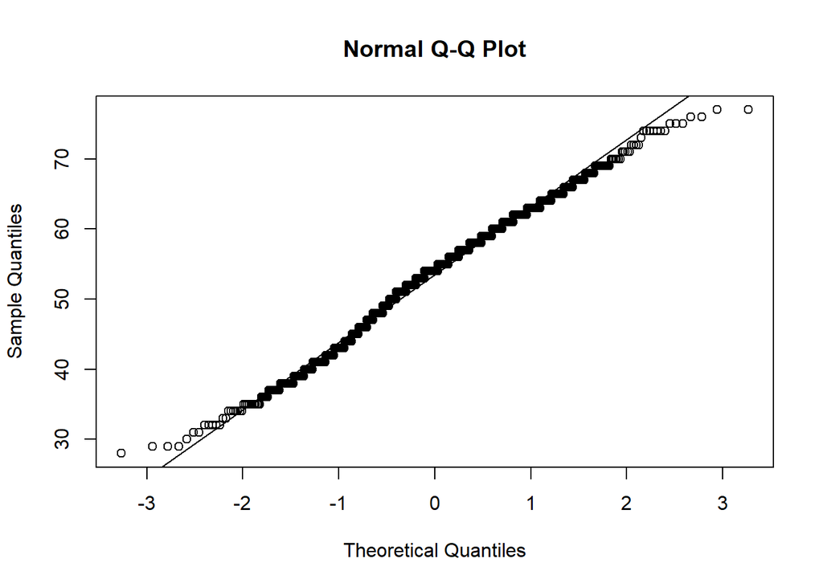

```r
qqnorm(heart$Age)
qqline(heart$Age)
```

A simple vista, se puede ver que los datos están por la recta menos por los lados por ello no podríamos asumir la normalidad. Tendremos que comprobarlo con el test de shapiro y Lilliefors.

```r
shapiro.test(heart$Age)
```

```
##
##  Shapiro-Wilk normality test
##
## data:  heart$Age
## W = 0.99101, p-value = 2.165e-05
```

```r
library(nortest)
lillie.test(heart$Age)
```

```
##
##  Lilliefors (Kolmogorov-Smirnov) normality test
##
## data:  heart$Age
## D = 0.063161, p-value = 3.158e-09
```

Obserando ambos test, se puede apreciar que la variable **Age**no sigue una distribución normal.

**RestingBP**

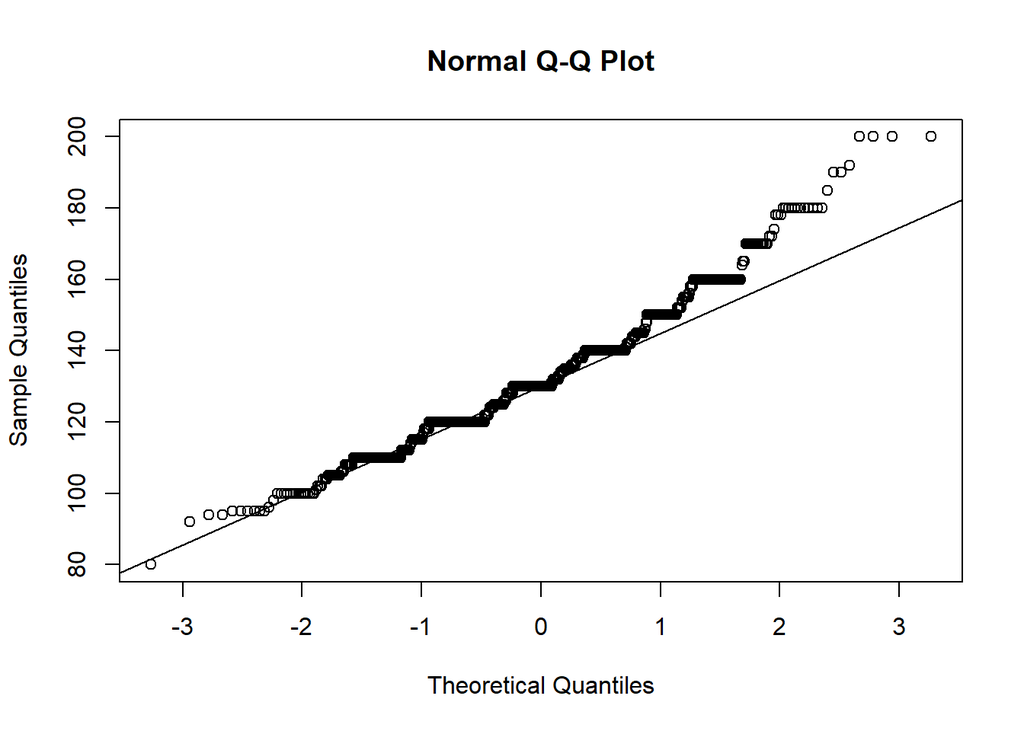

```r
qqnorm(heart$RestingBP)
qqline(heart$RestingBP)
```

Observando el gáfico la variable **RestingBP** no sigue una distribucción normal.

**Cholesterol**

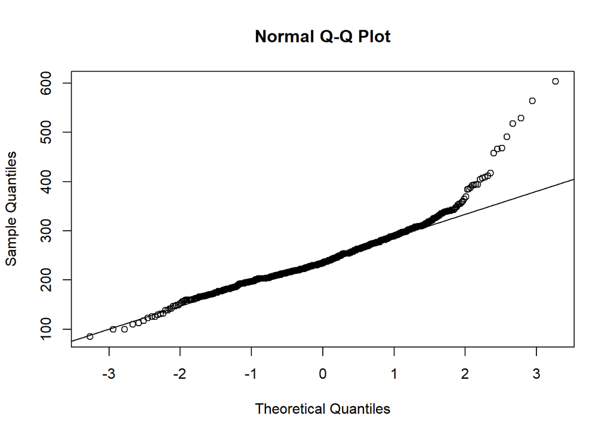

```r
qqnorm(heart$Cholesterol)
qqline(heart$Cholesterol)
```

Se aprecia en los extremos puntos muy distantes de la recta. Por ello, concluimos que el campo **Cholesterol** no sigue una distribución normal.

**MaxHR**

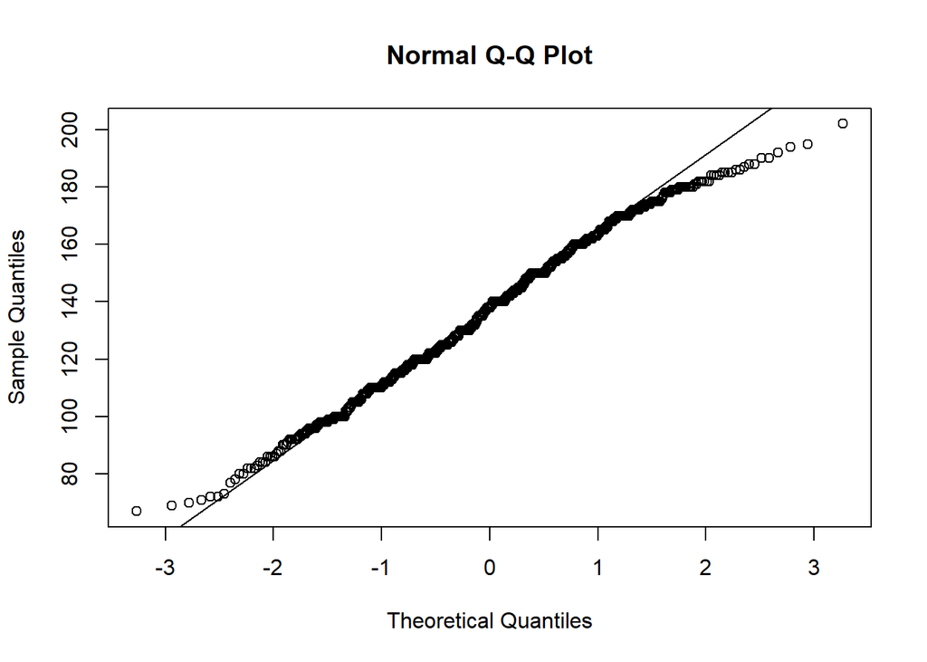

```r
qqnorm(heart$MaxHR)
qqline(heart$MaxHR)
```

Se observa que los puntos suelen seguir la recta, menos en loslados.

Para estar más seguros aplicamos los test de shapiro y Lilliefors.

```r
shapiro.test(heart$MaxHR)
```

```
##
##  Shapiro-Wilk normality test
##
## data:  heart$MaxHR
## W = 0.99239, p-value = 0.0001178
```

```r
lillie.test(heart$MaxHR)
```

```
##
##  Lilliefors (Kolmogorov-Smirnov) normality test
##
## data:  heart$MaxHR
## D = 0.047706, p-value = 4.03e-05
```

Según ambos test, la variable **MaxHR** no sigue una distribución normal.

**Oldpeak**

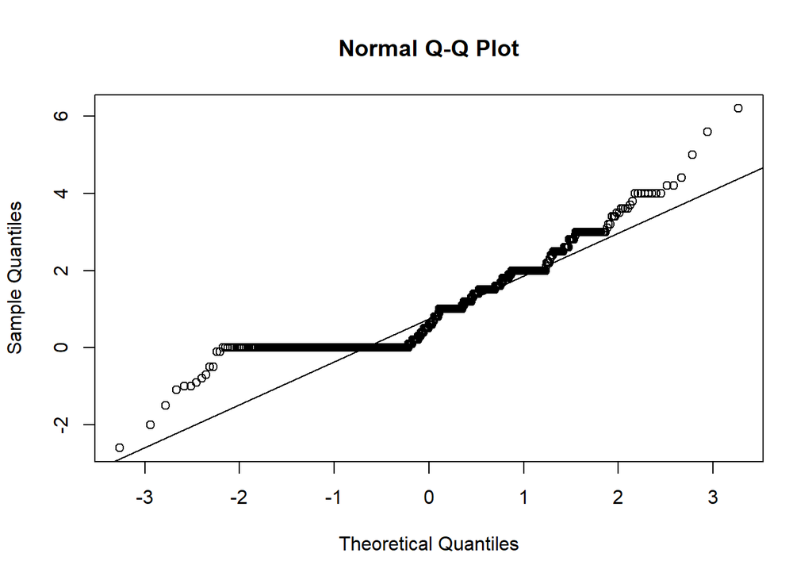

```r
qqnorm(heart$Oldpeak)
qqline(heart$Oldpeak)
```

A simple vista, se observa que muchos puntos están fuera de la recta y con esto podemos decir que no sigue una distribución normal.

**Age_nor**

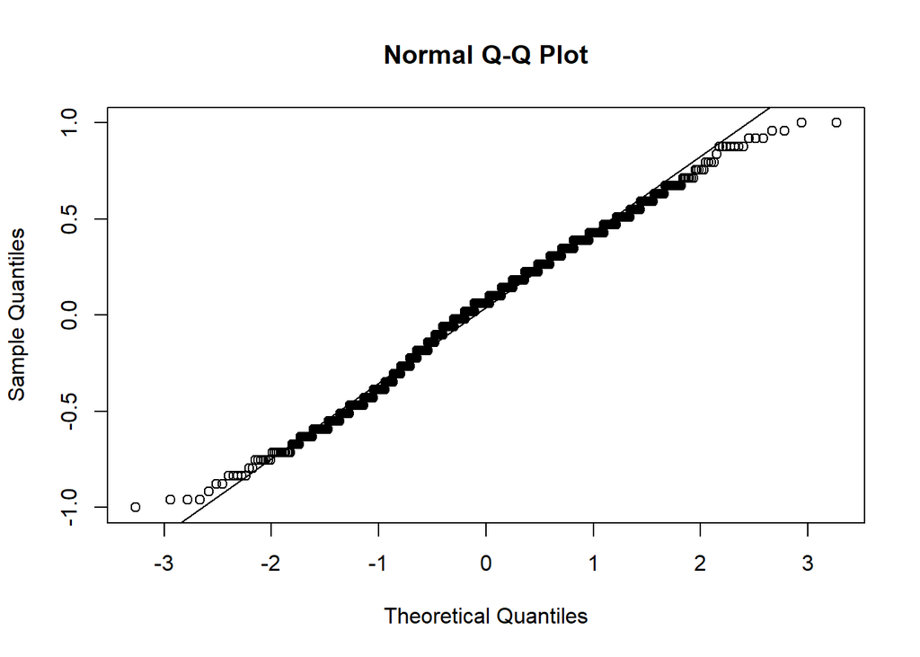

```r
qqnorm(heart$Age_nor)
qqline(heart$Age_nor)
```

Se aprecia que muchos puntos siguen la recta (similar a la variable Age sin normalizar ).

A continuación, aplicamos los siguientes test:

```r
shapiro.test(heart$Age_nor)
```

```
##
##  Shapiro-Wilk normality test
##
## data:  heart$Age_nor
## W = 0.99101, p-value = 2.165e-05
```

```r
lillie.test(heart$Age_nor)
```

```
##
##  Lilliefors (Kolmogorov-Smirnov) normality test
##
## data:  heart$Age_nor
## D = 0.063161, p-value = 3.158e-09
```

Nos da la misma información que la variable Age. Por tanto, podemos decir que no sigue una distribución normal.

## 4.3 Contraste de hipótesis

### 4.3.1 Queremos saber si el colesterol de las mujeres es mayor que el de los hombres

Primero, calculamos dos variables para obtener el colesterol de hombres y mujeres.

```r
colHom <- heart$Cholesterol[heart$Sex=="M"]

colMuj <- heart$Cholesterol[heart$Sex=="F"]
```

Como hipótesis nula, indicamos que el colesterol de las mujeres es igual que al de los hombres.

Como hipótesis alternativa indicamos que el colesterol de las mujeres es mayor que el de los hombres.

$$\left\{
\begin{array}{ll}
H_{0}: & \mu_M=\mu_H \\
H_{1}: & \mu_M>\mu_H
\end{array}
\right.\\
\ Hipótesis\ unilateral$$
Por el teorema del límite central, podemos asumir normalidad, puesto que tenemos una muestra de tamaño grande n y se desea realizar un test sobre la media. Por tanto, aplicamos un test de hipótesis de dos muestras sobre la media.

Aplicaremos la distribución t, dado que no se conoce la varianza de la población.

Es un test unilateral por la derecha.

Ahora, comprobamos la homocedasticidad.

```r
var.test(colMuj, colHom)
```

```
##
##  F test to compare two variances
##
## data:  colMuj and colHom
## F = 1.3623, num df = 192, denom df = 724, p-value = 0.005232
## alternative hypothesis: true ratio of variances is not equal to 1
## 95 percent confidence interval:
##  1.095376 1.719717
## sample estimates:
## ratio of variances
##           1.362271
```

Se observa que p-value < 0.05. Por tanto, las varianzas no son iguales.

Calculamos manualmente este constraste:

```r
alfa <- 1-0.95

n1 <- length(colMuj)
n2 <- length(colHom)
s1 <- sd(colMuj)
s2 <- sd(colHom)

mean1 <- mean(colMuj)
mean2 <- mean(colHom)
tobs <- (mean1-mean2) / (sqrt(s1^2/n1 + s2^2/n2))

df <- ((s1^2/n1 + s2^2/n2)^2) / ((s1^2/n1)^2/(n1-1) + (s2^2/n2)^2/(n2-1))

tcritU <- qt(alfa,df,lower.tail = FALSE)

pvalue <-pt( tobs,df, lower.tail=FALSE)

paste("Estadistico de contraste: ",tobs)
```

```
## [1] "Estadistico de contraste:  3.42626410131525"
```

```r
paste("Valor crítico: ",tcritU)
```

```
## [1] "Valor crítico:  1.65048285147708"
```

```r
paste("Valor p: ",pvalue)
```

```
## [1] "Valor p:  0.000353335001749233"
```

```r
paste("Valor de df: ",df)
```

```
## [1] "Valor de df:  271.620206548746"
```

A continuación, aplicamos el test de este contraste de hipótesis para comprobar que nos da lo mismo.

```r
t.test( colMuj,colHom , var.equal=FALSE, alternative = "greater")
```

```
##
##  Welch Two Sample t-test
##
## data:  colMuj and colHom
## t = 3.4263, df = 271.62, p-value = 0.0003533
## alternative hypothesis: true difference in means is greater than 0
## 95 percent confidence interval:
##  8.591104      Inf
## sample estimates:
## mean of x mean of y
##  256.0933  239.5172
```

Se aprecia, que p-value < 0.05. Por tanto, se rechaza la hipótesis nula y se acepta la alternativa de que las mujeres tiene más colesterol que los hombres.

### 4.3.2 Azúcar en sangre es mayor en hombres que en mujeres teniendo ambos enfermedades cardíacas

Primero, calculamos dos variables para obtener las enfermedades cardíacas de hombres y mujeres.

```r
carHom <- heart$FastingBS[heart$Sex=="M" & heart$HeartDisease=="1"]

carMuj <- heart$FastingBS[heart$Sex=="F" & heart$HeartDisease=="1"]
```

Como hipótesis nula, se quiere saber si las enfermedades cardíacas es igual en hombres que en mujeres.

Como hipótesis alternativa se quiere saber si las enfermedades cardíacas es mayor en hombres que en mujeres.

$$\left\{
\begin{array}{ll}
H_{0}: & \mu_H=\mu_M \\
H_{1}: & \mu_H>\mu_M
\end{array}
\right.\\
\ Hipótesis\ unilateral$$

Por el teorema del límite central, podemos asumir normalidad, puesto que tenemos una muestra de tamaño grande n y se desea realizar un test sobre la media. Por tanto, aplicamos un test de hipótesis de dos muestras sobre la media.

Aplicaremos la distribución t, dado que no se conoce la varianza de la población.

Es un test unilateral por la derecha.

Ahora, comprobamos la homocedasticidad.

```r
var.test(carHom,carMuj)
```

```
##
##  F test to compare two variances
##
## data:  carHom and carMuj
## F = 1.0073, num df = 457, denom df = 49, p-value = 0.9818
## alternative hypothesis: true ratio of variances is not equal to 1
## 95 percent confidence interval:
##  0.6381553 1.4800765
## sample estimates:
## ratio of variances
##           1.007349
```

Se observa que p-value > 0.05. Por tanto, las varianzas son iguales.

A continuación, aplicamos el test de este contraste de hipótesis.

```r
alfa <- 1-0.95

n1 <- length(carHom)
n2 <- length(carMuj)
s1 <- sd(carHom)
s2 <- sd(carMuj)

mean1 <- mean(carHom)
mean2 <- mean(carMuj)


df <- n1+n2-2

S <- sqrt( ( (n1-1)*s1^2 + (n2-1)*s2^2 ) / (n1+n2-2) )

 tobs <- (mean1-mean2) / (S * sqrt(1/n1 + 1/n2))
 tcritL <- qt( alfa/2, n1+n2-2)
 tcritU <- qt( 1-alfa/2, n1+n2-2)
 pvalue <-pt( abs(tobs), df=n1+n2-2, lower.tail=FALSE)


paste("Estadistico de contraste: ",tobs)
```

```
## [1] "Estadistico de contraste:  0.230696223146016"
```

```r
paste("Valor crítico: ",tcritU)
```

```
## [1] "Valor crítico:  1.96466331119118"
```

```r
paste("Valor p: ",pvalue)
```

```
## [1] "Valor p:  0.408822025940827"
```

```r
paste("Valor de df: ",df)
```

```
## [1] "Valor de df:  506"
```

Aplicamos el test para comprobar si nos da el mismo resultado.

```r
t.test( carHom,carMuj , var.equal=TRUE, alternative = "greater")
```

```
##
##  Two Sample t-test
##
## data:  carHom and carMuj
## t = 0.2307, df = 506, p-value = 0.4088
## alternative hypothesis: true difference in means is greater than 0
## 95 percent confidence interval:
##  -0.09979074         Inf
## sample estimates:
## mean of x mean of y
## 0.3362445 0.3200000
```

Se aprecia, que p-value > 0.05. Por tanto, se acepta la hipótesis nula de que los hombres con enfermedad cardíaca tienen igual azúcar en sangre que las mujeres con enfermedad cardíaca.

## 4.4 Estudio de correlación entre las variables

En este apartado queremos representar la matriz de correlación del dataset.

Utilizamos el dataset utilizado para el análisis anterior de PCA

Calculamos la correlación de las variables usando el método de pearson.

```r
Corelacion <- cor(heart_num,method="pearson")
Corelacion
```

```
##                         Age          Sex ChestPainType    RestingBP
## Age             1.000000000 -0.055750099   -0.07715013  0.263101716
## Sex            -0.055750099  1.000000000    0.12655877 -0.009502133
## ChestPainType  -0.077150132  0.126558765    1.00000000 -0.010820389
## RestingBP       0.263101716 -0.009502133   -0.01082039  1.000000000
## Cholesterol     0.035949480  0.122833668   -0.07645522  0.092483840
## FastingBS       0.198039066 -0.120075988   -0.07315099  0.067728664
## RestingECG     -0.007484033 -0.071552184   -0.07253685  0.023456877
## MaxHR          -0.384306668  0.187173215    0.28583652 -0.108506017
## ExerciseAngina  0.215792691 -0.190664102   -0.35472729  0.152883307
## Oldpeak         0.258611536 -0.105733537   -0.17737737  0.174304136
## ST_Slope       -0.268263994  0.150692544    0.21352120 -0.082226847
## HeartDisease    0.282038506 -0.305444916   -0.38682769  0.118070714
##                 Cholesterol   FastingBS   RestingECG        MaxHR
## Age             0.035949480  0.19803907 -0.007484033 -0.384306668
## Sex             0.122833668 -0.12007599 -0.071552184  0.187173215
## ChestPainType  -0.076455221 -0.07315099 -0.072536854  0.285836516
## RestingBP       0.092483840  0.06772866  0.023456877 -0.108506017
## Cholesterol     1.000000000  0.01262851 -0.091593724 -0.005341853
## FastingBS       0.012628509  1.00000000  0.087049561 -0.136763624
## RestingECG     -0.091593724  0.08704956  1.000000000 -0.180854165
## MaxHR          -0.005341853 -0.13676362 -0.180854165  1.000000000
## ExerciseAngina  0.090879090  0.06045067  0.077500389 -0.372902545
## Oldpeak         0.048075140  0.05269786 -0.020437522 -0.166729389
## ST_Slope       -0.061766760 -0.17577434 -0.006778212  0.348051929
## HeartDisease    0.083198713  0.26729119  0.057384357 -0.397592228
##                ExerciseAngina     Oldpeak     ST_Slope HeartDisease
## Age                0.21579269  0.25861154 -0.268263994   0.28203851
## Sex               -0.19066410 -0.10573354  0.150692544  -0.30544492
## ChestPainType     -0.35472729 -0.17737737  0.213521201  -0.38682769
## RestingBP          0.15288331  0.17430414 -0.082226847   0.11807071
## Cholesterol        0.09087909  0.04807514 -0.061766760   0.08319871
## FastingBS          0.06045067  0.05269786 -0.175774343   0.26729119
## RestingECG         0.07750039 -0.02043752 -0.006778212   0.05738436
## MaxHR             -0.37290255 -0.16672939  0.348051929  -0.39759223
## ExerciseAngina     1.00000000  0.40875250 -0.428705943   0.49428199
## Oldpeak            0.40875250  1.00000000 -0.501921270   0.40395072
## ST_Slope          -0.42870594 -0.50192127  1.000000000  -0.55877071
## HeartDisease       0.49428199  0.40395072 -0.558770715   1.00000000
```

A continuación, representamos la matriz de correlación.

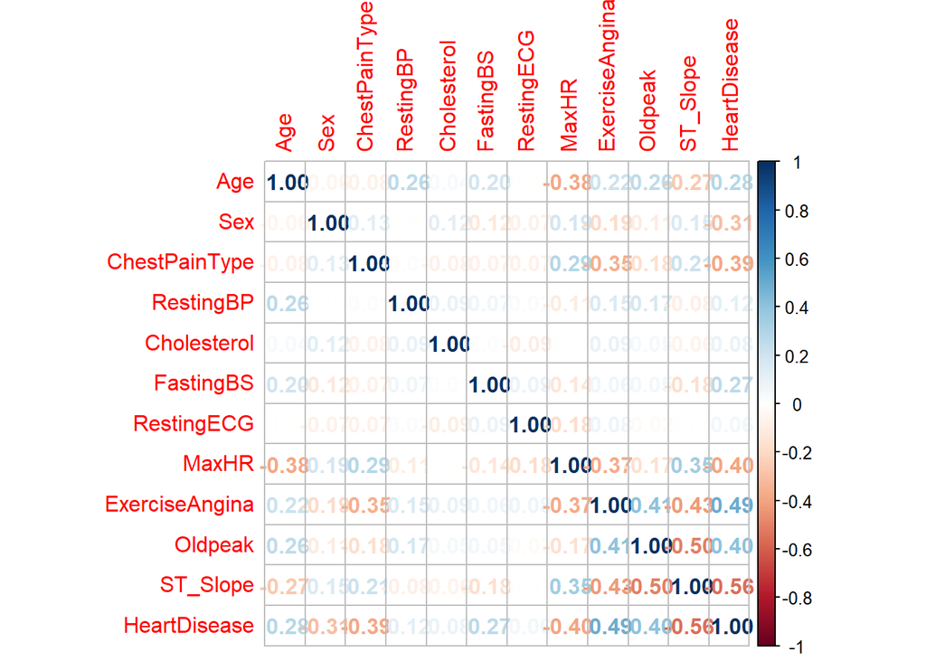

```r
if (!require('corrplot')) install.packages('corrplot'); library('corrplot')
corrplot(Corelacion, method = "number")
```

A partir de aqui, podemos observar lo siguiente:

Si observamos la variable que consideramos más importante en nuestro dataset, **HeartDisease**, podemos decir que aquellas variables que tienen más correlación son: **MaxHR**, **ExerciseAngina**,**Olpeak** y **ST_Slope**.

Este análisis previo nos servirá para en los modelos de regresión siguientes identificar cuales podrían ser aquellas variables independientes más importantes.

## 4.5 Regresión lineal

### 4.5.1 Regresión lineal simple

En primer lugar, realizamos un modelo de regresión lineal simple cuya variable dependiente es MaxHR y independiente es Age.

```r
Model_reg_sim <- lm(MaxHR~Age,data=heart)
summary(Model_reg_sim)
```

```
##
## Call:
## lm(formula = MaxHR ~ Age, data = heart)
##
## Residuals:
##     Min      1Q  Median      3Q     Max
## -70.879 -15.933   0.938  18.066  58.507
##
## Coefficients:
##              Estimate Std. Error t value Pr(>|t|)
## (Intercept) 191.97996    4.43148   43.32   <2e-16 ***
## Age          -1.02754    0.08156  -12.60   <2e-16 ***
## ---
## Signif. codes:  0 '***' 0.001 '**' 0.01 '*' 0.05 '.' 0.1 ' ' 1
##
## Residual standard error: 23.3 on 916 degrees of freedom
## Multiple R-squared:  0.1477, Adjusted R-squared:  0.1468
## F-statistic: 158.7 on 1 and 916 DF,  p-value: < 2.2e-16
```

Se observa que el coeficiente de determinación ajustado es bajo: 14.6%.

### 4.5.2 Regresión lineal múltiple

Se crea un modelo de regresión lineal múltiple con la variable dependiente **MaxHR** y indpendientes: **HeartDisease**, **ST_Slope**, **FastingBS**, **Oldpeak**, **RestingECG**, **Sex**, **Cholesterol**.

```r
Model_reg_mul <- lm(MaxHR~Age+HeartDisease+ST_Slope+FastingBS+Oldpeak+RestingECG+Sex+Cholesterol,data=heart)
summary(Model_reg_mul)
```

```
##
## Call:
## lm(formula = MaxHR ~ Age + HeartDisease + ST_Slope + FastingBS +
##     Oldpeak + RestingECG + Sex + Cholesterol, data = heart)
##
## Residuals:
##    Min     1Q Median     3Q    Max
## -75.52 -13.35   0.41  15.35  57.48
##
## Coefficients:
##                    Estimate Std. Error t value Pr(>|t|)
## (Intercept)      192.189947   6.728604  28.563  < 2e-16 ***
## Age               -0.837303   0.080857 -10.355  < 2e-16 ***
## HeartDisease      -9.084096   1.961702  -4.631 4.18e-06 ***
## ST_SlopeFlat      -1.535571   2.962891  -0.518  0.60440
## ST_SlopeUp        10.238561   3.298723   3.104  0.00197 **
## FastingBS          1.342525   1.749232   0.767  0.44299
## Oldpeak            1.944141   0.782412   2.485  0.01314 *
## RestingECGNormal  -9.617849   1.827829  -5.262 1.78e-07 ***
## RestingECGST     -12.942031   2.234606  -5.792 9.60e-09 ***
## SexM              -4.964359   1.826623  -2.718  0.00670 **
## Cholesterol        0.004842   0.012963   0.374  0.70883
## ---
## Signif. codes:  0 '***' 0.001 '**' 0.01 '*' 0.05 '.' 0.1 ' ' 1
##
## Residual standard error: 21.13 on 907 degrees of freedom
## Multiple R-squared:  0.3057, Adjusted R-squared:  0.2981
## F-statistic: 39.94 on 10 and 907 DF,  p-value: < 2.2e-16
```

Se aprecia un coeficiente de determinación bajo (30%).

Podemos considerar que estos modelos no son validos.

## 4.6 Regresión logística

### 4.6.1 Regresión logística simple

Vamos a crear una regresión logística simple como variable dependiente **HeartDisease** y independiente **MaxHR**.

```r
model_logis1 <- glm(formula=HeartDisease~MaxHR,data=heart,family=binomial())
summary(model_logis1)
```

```
##
## Call:
## glm(formula = HeartDisease ~ MaxHR, family = binomial(), data = heart)
##
## Deviance Residuals:
##     Min       1Q   Median       3Q      Max
## -2.3785  -1.0261   0.5797   0.9631   2.0105
##
## Coefficients:
##              Estimate Std. Error z value Pr(>|z|)
## (Intercept)  5.312314   0.462283   11.49   <2e-16 ***
## MaxHR       -0.036878   0.003277  -11.25   <2e-16 ***
## ---
## Signif. codes:  0 '***' 0.001 '**' 0.01 '*' 0.05 '.' 0.1 ' ' 1
##
## (Dispersion parameter for binomial family taken to be 1)
##
##     Null deviance: 1262.1  on 917  degrees of freedom
## Residual deviance: 1105.8  on 916  degrees of freedom
## AIC: 1109.8
##
## Number of Fisher Scoring iterations: 4
```

Calculamos la bondad de ajuste usando el test de hoslem.

```r
if (!require('ResourceSelection')) install.packages('ResourceSelection'); library('ResourceSelection')
```

```
## ResourceSelection 0.3-5   2019-07-22
```

```r
hoslem.test(heart$HeartDisease,fitted(model_logis1))
```

```
##
##  Hosmer and Lemeshow goodness of fit (GOF) test
##
## data:  heart$HeartDisease, fitted(model_logis1)
## X-squared = 15.098, df = 8, p-value = 0.05726
```

Se observa que p-value >0.05. Por tanto, el modelo ajusta bien los datos.

### 4.6.2 Regresión logística múltiple

En este modelo queremos conocer la probabilidad de una persona de sufrir una enfermedad cardíaca o no, dependiendo de una serie de variables independientes.

Calculamos una regresión logística múltiple con **HeartDisease** como variable dependiente y **ST_Slope**, **Oldpeak**, **MaxHR**, **ChestPainType**, **RestingBP**, **Age_nor** como variables dependientes

```r
model_logis2 <- glm(formula=HeartDisease~ST_Slope+Oldpeak+MaxHR+ChestPainType+RestingBP+Age_nor,data=heart,family=binomial())
summary(model_logis2)
```

```
##
## Call:
## glm(formula = HeartDisease ~ ST_Slope + Oldpeak + MaxHR + ChestPainType +
##     RestingBP + Age_nor, family = binomial(), data = heart)
##
## Deviance Residuals:
##     Min       1Q   Median       3Q      Max
## -2.6439  -0.4265   0.2657   0.4951   2.5609
##
## Coefficients:
##                   Estimate Std. Error z value Pr(>|z|)
## (Intercept)       2.310735   0.987247   2.341 0.019254 *
## ST_SlopeFlat      0.900785   0.396679   2.271 0.023158 *
## ST_SlopeUp       -1.417499   0.413301  -3.430 0.000604 ***
## Oldpeak           0.422374   0.108012   3.910 9.21e-05 ***
## MaxHR            -0.013499   0.004404  -3.065 0.002175 **
## ChestPainTypeATA -2.288611   0.296705  -7.713 1.22e-14 ***
## ChestPainTypeNAP -1.778255   0.233869  -7.604 2.88e-14 ***
## ChestPainTypeTA  -1.593164   0.393194  -4.052 5.08e-05 ***
## RestingBP         0.003921   0.005694   0.689 0.490997
## Age_nor           0.556923   0.290248   1.919 0.055012 .
## ---
## Signif. codes:  0 '***' 0.001 '**' 0.01 '*' 0.05 '.' 0.1 ' ' 1
##
## (Dispersion parameter for binomial family taken to be 1)
##
##     Null deviance: 1262.14  on 917  degrees of freedom
## Residual deviance:  695.39  on 908  degrees of freedom
## AIC: 715.39
##
## Number of Fisher Scoring iterations: 5
```

## 4.7 Se aprecia que el AIC es mucho menor y por tanto, el modelo es mejor.

Calculamos la bondad de ajuste:

```r
hoslem.test(heart$HeartDisease,fitted(model_logis2))
```

```
##
##  Hosmer and Lemeshow goodness of fit (GOF) test
##
## data:  heart$HeartDisease, fitted(model_logis2)
## X-squared = 12.797, df = 8, p-value = 0.119
```

Se aprecia que el modelo tiene p-value > 0.05. Por tanto, ajusta bien los datos.

Vamos a dividir el conjunto de los datos en un conjunto de entrenamiento y otro de prueba para validar el modelo.

```r
set.seed(42)
index <- sample(1:nrow(heart),size = floor(0.80*nrow(heart)))

train <- heart[index,]
test <- heart[-index,]
```

```r
model_logis3 <- glm(formula=HeartDisease~ST_Slope+Oldpeak+MaxHR+ChestPainType+RestingBP+Age_nor,data=train,family=binomial())
summary(model_logis3)
```

```
##
## Call:
## glm(formula = HeartDisease ~ ST_Slope + Oldpeak + MaxHR + ChestPainType +
##     RestingBP + Age_nor, family = binomial(), data = train)
##
## Deviance Residuals:
##     Min       1Q   Median       3Q      Max
## -2.5513  -0.4473   0.2596   0.4874   2.4474
##
## Coefficients:
##                   Estimate Std. Error z value Pr(>|z|)
## (Intercept)       1.654305   1.099844   1.504 0.132549
## ST_SlopeFlat      0.972398   0.459706   2.115 0.034408 *
## ST_SlopeUp       -1.406658   0.481448  -2.922 0.003481 **
## Oldpeak           0.357051   0.121739   2.933 0.003358 **
## MaxHR            -0.012823   0.004869  -2.634 0.008445 **
## ChestPainTypeATA -2.182909   0.319129  -6.840 7.91e-12 ***
## ChestPainTypeNAP -1.674384   0.260865  -6.419 1.38e-10 ***
## ChestPainTypeTA  -1.569842   0.433376  -3.622 0.000292 ***
## RestingBP         0.007601   0.006512   1.167 0.243074
## Age_nor           0.533579   0.324806   1.643 0.100432
## ---
## Signif. codes:  0 '***' 0.001 '**' 0.01 '*' 0.05 '.' 0.1 ' ' 1
##
## (Dispersion parameter for binomial family taken to be 1)
##
##     Null deviance: 1014.9  on 733  degrees of freedom
## Residual deviance:  564.2  on 724  degrees of freedom
## AIC: 584.2
##
## Number of Fisher Scoring iterations: 5
```

```r
predicion_1 <- ifelse(predict(model_logis3,newdata = test, type="response") >=0.5,1,0)
predicion_1
```

```
##   5   6  15  38  43  48  50  51  52  55  64  70  81  89  90  93 122 140 151 160
##   0   0   0   0   0   0   1   1   1   1   1   0   0   0   1   0   0   1   0   0
## 167 191 194 199 205 209 217 221 234 257 263 270 272 282 289 290 293 300 302 306
##   1   0   0   1   0   0   1   1   0   0   1   1   0   1   0   0   0   0   0   1
## 310 322 333 334 336 338 340 347 350 353 361 371 380 384 385 386 392 394 396 399
##   1   1   0   0   1   1   1   1   1   1   1   0   0   1   1   1   1   1   1   1
## 400 411 412 413 415 416 420 428 434 436 437 439 440 445 448 453 459 461 465 467
##   1   1   1   1   1   1   1   1   1   1   1   1   0   1   1   1   1   1   1   1
## 477 478 479 480 484 485 487 488 490 492 494 495 497 498 503 505 507 510 519 520
##   0   1   1   1   1   1   0   1   1   1   1   1   1   1   1   1   1   1   0   1
## 521 525 528 530 534 536 545 548 549 551 553 562 564 571 574 579 581 582 583 588
##   1   0   0   1   1   1   0   1   1   1   1   0   1   1   1   1   1   0   1   0
## 590 593 597 602 608 610 611 613 617 631 633 639 644 651 652 660 661 674 675 680
##   1   1   1   1   1   1   1   1   1   1   1   0   1   0   1   1   0   1   1   1
## 688 695 699 702 708 712 713 714 717 723 724 726 740 743 745 746 748 749 756 759
##   0   0   1   0   1   1   0   0   1   1   0   1   0   0   0   1   0   1   1   0
## 763 769 778 780 782 787 793 801 802 812 820 833 844 852 862 864 870 877 878 892
##   1   1   0   0   0   1   1   0   1   1   1   0   0   0   0   1   0   1   1   1
## 896 899 906 910
##   1   0   1   1
```

```r
mat_conf_1<-table(test$HeartDisease,Predicted=predicion_1)
mat_conf_1
```

```
##    Predicted
##       0   1
##   0  51  14
##   1  12 107
```

```r
if(!require(gmodels)){
    install.packages('gmodels', repos='http://cran.us.r-project.org')
    library(gmodels)
}
CrossTable(test$HeartDisease,predicion_1,prop.chisq  = FALSE, prop.c = FALSE, prop.r =FALSE,dnn = c('Reality', 'Prediction'))
```

```
##
##
##    Cell Contents
## |-------------------------|
## |                       N |
## |         N / Table Total |
## |-------------------------|
##
##
## Total Observations in Table:  184
##
##
##              | Prediction
##      Reality |         0 |         1 | Row Total |
## -------------|-----------|-----------|-----------|
##            0 |        51 |        14 |        65 |
##              |     0.277 |     0.076 |           |
## -------------|-----------|-----------|-----------|
##            1 |        12 |       107 |       119 |
##              |     0.065 |     0.582 |           |
## -------------|-----------|-----------|-----------|
## Column Total |        63 |       121 |       184 |
## -------------|-----------|-----------|-----------|
##
##
```

```r
print(sprintf("La precisión del modelo es: %.4f %%",100*(158/184)))
```

```
## [1] "La precisión del modelo es: 85.8696 %"
```

## 4.8 Modelos de clasificación

El objetivo de este modelo es clasificar adecuadamente aquellas personas según los datos dados para cada variable si va a sufrir una enfermedad cardíaca o no.

### 4.8.1 Preparación de los datos para el modelo

Nos interesa desordenar los datos para poder elegir registros aleatorios. Guardaremos los datos con el nuevo nombre de: **heart_clasification**

```r
set.seed(1)
heart_clasification <- heart[sample(nrow(heart)),]
```

Para la futura evaluación del árbol de decisión, es necesario dividir el conjunto de datos en un conjunto de entrenamiento y un conjunto de prueba. El conjunto de entrenamiento es el subconjunto del conjunto original de datos utilizado para construir un primer modelo; y el conjunto de prueba, el subconjunto del conjunto original de datos utilizado para evaluar la calidad del modelo.

Lo más correcto será utilizar un conjunto de datos diferente del que utilizamos para construir el árbol, es decir, un conjunto diferente del de entrenamiento. No hay ninguna proporción fijada con respecto al número relativo de componentes de cada subconjunto, pero la más utilizada acostumbra a ser 2/3 para el conjunto de entrenamiento y 1/3, para el conjunto de prueba.

```r
set.seed(666)
y <- heart_clasification[,12]
X <- heart_clasification[,1:11]
```

Dividimos el dataset en dos partes diferenciadas, train y test. Podemos crear directamente un rango utilizando el parámetro split_prop

```r
split_prop <- 3
indexes = sample(1:nrow( heart_clasification), size=floor(((split_prop-1)/split_prop)*nrow(heart_clasification)))
trainx<-X[indexes,]
trainy<-y[indexes]
testx<-X[-indexes,]
testy<-y[-indexes]
```

### 4.8.2 Creación del modelo, calidad del modelo y extracción de reglas

```r
if(!require(ggplot2)){
    install.packages('ggplot2', repos='http://cran.us.r-project.org')
    library(ggplot2)
}
if(!require(ggpubr)){
    install.packages('ggpubr', repos='http://cran.us.r-project.org')
    library(ggpubr)
}
if(!require(grid)){
    install.packages('grid', repos='http://cran.us.r-project.org')
    library(grid)
}

if(!require(gridExtra)){
    install.packages('gridExtra', repos='http://cran.us.r-project.org')
    library(gridExtra)
}
if(!require(C50)){
    install.packages('C50', repos='http://cran.us.r-project.org')
    library(C50)
}
library("rpart")
library("rpart.plot")
```

```r
if(!require(C50)){
    install.packages('C50', repos='http://cran.us.r-project.org')
    library(C50)
}
trainy = as.factor(trainy)
modelo_clasificacion_C50 <- C50::C5.0(trainx, trainy,rules=TRUE,control = C5.0Control(noGlobalPruning = FALSE) )
summary(modelo_clasificacion_C50)
```

```
##
## Call:
## C5.0.default(x = trainx, y = trainy, rules = TRUE, control
##  = C5.0Control(noGlobalPruning = FALSE))
##
##
## C5.0 [Release 2.07 GPL Edition]      Sun Dec 26 14:05:15 2021
## -------------------------------
##
## Class specified by attribute `outcome'
##
## Read 612 cases (12 attributes) from undefined.data
##
## Rules:
##
## Rule 1: (77/1, lift 2.0)
##  Sex = F
##  RestingBP <= 148
##  FastingBS <= 0
##  ExerciseAngina = N
##  ->  class 0  [0.975]
##
## Rule 2: (40/3, lift 1.9)
##  ChestPainType = NAP
##  RestingBP <= 132
##  MaxHR > 150
##  ->  class 0  [0.905]
##
## Rule 3: (72/8, lift 1.8)
##  ChestPainType in {ATA, TA}
##  MaxHR > 150
##  ->  class 0  [0.878]
##
## Rule 4: (272/46, lift 1.7)
##  ST_Slope = Up
##  ->  class 0  [0.828]
##
## Rule 5: (50, lift 1.9)
##  ChestPainType = ASY
##  RestingBP <= 131
```

[output cut: 67 more lines]

```
##
##  Attribute usage:
##
##  100.00% ST_Slope
##   48.69% ChestPainType
##   38.24% FastingBS
##   35.62% Sex
##   29.90% ExerciseAngina
##   27.12% RestingBP
##   21.24% Oldpeak
##   19.77% MaxHR
##   16.01% Cholesterol
##
##
## Time: 0.0 secs
```

Se observa que los atributos que más se usan en este modelo son “ST_Slope” con un 100% y “ChestPainType” con un 48.69%. El modelo obtenido se ha clasificado con un 8.0% de errores, lo que se supone que hay un 92% de aciertos.

Además, se han obtenido una serie de reglas que el modelo ha acogido como decisivas para observar si una persona tiene riesgo de enfermedad del corazón. Todas estas se explican a continuación:

```
1. Si una persona es de género femenino, tiene una presión arterial menor o igual que 148, un azúcar en sangre menor o igual a 0 y no tiene angina inducida por el ejercicio, no tendrá enfermedad del corazón con un 97.5%.

2. Una persona con dolor de pecho NAP, una presión arterial menor o igual que 132, una máxima frecuencia cardíaca de 150, tendrá una probabilidad de no tener enfermedad del corazón con un 90.5%.

3. Con una probabilidad del 87.8%, una persona con dolor de pecho ATA/TA y una máxima frecuencia cardíaca mayor que 150, no tednrá una enfermedad cardíaca.

4. Una persona cuyo ST_Slope es Up, no tendrá una enfermedad del corazón con un 82.8%.

5. Una persona con dolor de epcho ASY, una presión arterial menor o igual que 131, azúcar en sangre mayor que 0, tendrá una enfermedad cardíaca con una probabilidad de 98.1%.

6. Con una probabilidad del 96%, una persona con dolor de pecho ASY, el colesterol menor o igual a 197 y con angina inducida por el ejercicio, tendrá una enfermedad del corazón.

7. Una persona con dolor de pecho ASY, azúcar en sangre mayor que 0 y un Oldpeak de 0.6, tendrá enfermedad del corazon con un 95.2%.

8. Con una probabilidad del 94.8%, un hombre con dolor de pecho  ASY, colesterol mayor que 227, azúcar en sangre menor o igual a 0, con dolor de angina inducida por el ejercicio, tendrá enfermedad del corazón.

9. Un hombre con Oldpeak menor o igual a 0.3 y con ST_Slope down/flat, tendrá una enfermedad del corazón con un 93.9%.

10. Un hombre con dolor de pecho ASY, azúcar en sangre menor o igual a 126, una máxima frecuencia cardíaca entre 146-160 y un ST_Slope Up, tendrá una enfermedad cardíaca con un 90.9%.

11. Una persona con dolor de pecho ASY , azúcar en sangre menor o igual a 126, sin dolor de angina inducida por el ejercicio, con  Oldpeak mayor que  0.4 y ST_Slope  Up, tendrá enfermedad del corazón con un 90%.

12. Una persona con ST_Slope down/flat, tendrá una enfermedad cardíaca con un 80.1%.
```

```r
predicted_model <- predict( modelo_clasificacion_C50, testx, type="class" )
print(sprintf("La precisión del modelo es: %.4f %%",100*sum(predicted_model == testy) / length(predicted_model)))
```

```
## [1] "La precisión del modelo es: 85.2941 %"
```

### 4.8.3 Arbol de decisión con el método rpart

Se crea el árbol de decisión usando los datos de entrenamiento:

Utilizaremos dos bibliotecas diferentes, una de ellas es rpart, para crear el árbol de decisión y rpart.plot para representar visualmente nuestro árbol de decisión.

```r
modelo_clasificacion_rpart <- rpart(formula = trainy ~ ., data = trainx, method = "class" )
```

```r
summary(modelo_clasificacion_rpart)
```

```
## Call:
## rpart(formula = trainy ~ ., data = trainx, method = "class")
##   n= 612
##
##           CP nsplit rel error    xerror       xstd
## 1 0.61433447      0 1.0000000 1.0000000 0.04217798
## 2 0.02559727      1 0.3856655 0.3856655 0.03276017
## 3 0.02389078      3 0.3344710 0.4061433 0.03341593
## 4 0.01365188      5 0.2866894 0.3412969 0.03121703
## 5 0.01000000      7 0.2593857 0.3276451 0.03070557
##
## Variable importance
##       ST_Slope        Oldpeak  ChestPainType ExerciseAngina          MaxHR
##             30             18             16             13             13
##            Age            Sex    Cholesterol      RestingBP
##              6              2              1              1
##
## Node number 1: 612 observations,    complexity param=0.6143345
##   predicted class=1  expected loss=0.4787582  P(node) =1
##     class counts:   293   319
##    probabilities: 0.479 0.521
##   left son=2 (272 obs) right son=3 (340 obs)
##   Primary splits:
##       ST_Slope       splits as  RRL,       improve=121.41240, (0 missing)
##       ChestPainType  splits as  RLLL,      improve= 90.58827, (0 missing)
##       ExerciseAngina splits as  LR,        improve= 80.19091, (0 missing)
##       Oldpeak        < 0.45  to the left,  improve= 53.26917, (0 missing)
##       MaxHR          < 150.5 to the right, improve= 47.53931, (0 missing)
##   Surrogate splits:
##       Oldpeak        < 0.35  to the left,  agree=0.775, adj=0.493, (0 split)
##       ExerciseAngina splits as  LR,        agree=0.717, adj=0.364, (0 split)
##       ChestPainType  splits as  RLLL,      agree=0.699, adj=0.324, (0 split)
##       MaxHR          < 152.5 to the right, agree=0.686, adj=0.294, (0 split)
##       Age            < 54.5  to the left,  agree=0.629, adj=0.165, (0 split)
##
## Node number 2: 272 observations,    complexity param=0.02559727
##   predicted class=0  expected loss=0.1691176  P(node) =0.4444444
##     class counts:   226    46
##    probabilities: 0.831 0.169
##   left son=4 (185 obs) right son=5 (87 obs)
```

[output cut: 112 more lines]

```
##
## Node number 15: 246 observations
##   predicted class=1  expected loss=0.08130081  P(node) =0.4019608
##     class counts:    20   226
##    probabilities: 0.081 0.919
##
## Node number 28: 16 observations
##   predicted class=0  expected loss=0.25  P(node) =0.02614379
##     class counts:    12     4
##    probabilities: 0.750 0.250
##
## Node number 29: 20 observations
##   predicted class=1  expected loss=0.2  P(node) =0.03267974
##     class counts:     4    16
##    probabilities: 0.200 0.800
```

Vamos a representar gráficamente el arbol obtenido de dos maneras diferentes:

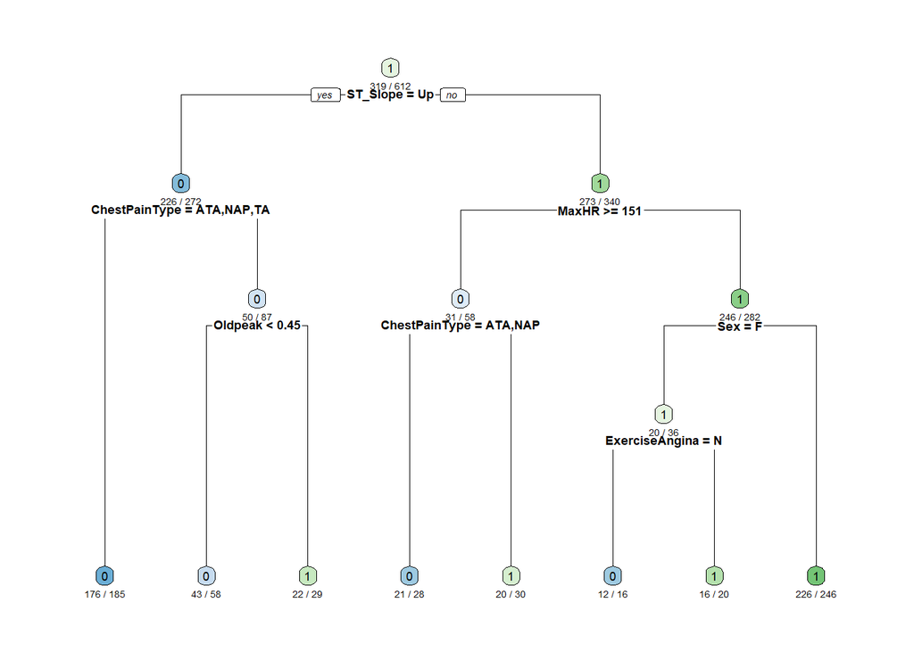

```r
rpart.plot(modelo_clasificacion_rpart, type=2,extra = 2, under = TRUE, faclen=5,cex=.55)
```

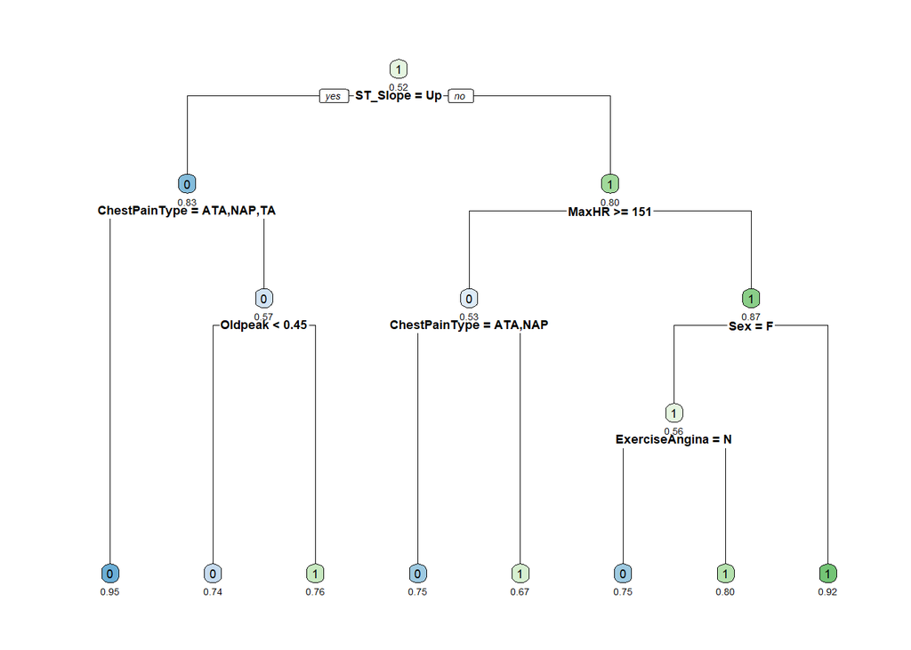

```r
rpart.plot(modelo_clasificacion_rpart, type=2,extra = 8, under = TRUE, faclen=5,cex=.55)
```

En el primer árbol Observamos las tasas de clasificación para cada nodo, expresada como el número de clasificaciones correctas y el número de observaciones en el nodo. En el segundo gráfico observamos la probabilidad por cada clase.

#### 4.8.3.1 Predición del modelo

```r
predicted_model <- predict( modelo_clasificacion_rpart, testx, type="class" )
print(sprintf("La precisión del modelo4 es: %.4f %%",100*sum(predicted_model == testy) / length(predicted_model)))
```

```
## [1] "La precisión del modelo4 es: 83.6601 %"
```

Vamos a crear la matriz de confusión

```r
mat_conf_2<-table(testy,Predicted=predicted_model)
mat_conf_2
```

```
##      Predicted
## testy   0   1
##     0  98  19
##     1  31 158
```

```r
CrossTable(testy, predicted_model,prop.chisq  = FALSE, prop.c = FALSE, prop.r =FALSE,dnn = c('Reality', 'Prediction'))
```

```
##
##
##    Cell Contents
## |-------------------------|
## |                       N |
## |         N / Table Total |
## |-------------------------|
##
##
## Total Observations in Table:  306
##
##
##              | Prediction
##      Reality |         0 |         1 | Row Total |
## -------------|-----------|-----------|-----------|
##            0 |        98 |        19 |       117 |
##              |     0.320 |     0.062 |           |
## -------------|-----------|-----------|-----------|
##            1 |        31 |       158 |       189 |
##              |     0.101 |     0.516 |           |
## -------------|-----------|-----------|-----------|
## Column Total |       129 |       177 |       306 |
## -------------|-----------|-----------|-----------|
##
##
```

```r
print(sprintf("La precisión del modelo4 es: %.4f %%",100*sum(predicted_model == testy) / length(predicted_model)))
```

```
## [1] "La precisión del modelo4 es: 83.6601 %"
```

### 4.8.4 Modelo con mejora adaptative boosting

A continuación, utilizamos otro enfoque para comparar los resultados: incorporar como novedad “adaptative boosting”. La idea de esta técnica es generar varios clasificadores, con sus correspondientes arboles de decisión y su ser de reglas. Cuando un nuevo caso va a ser clasificado, cada clasificador vota cual es la clase predicha. Los votos son sumados y determina la clase final.

```r
modelo_trials <- C50::C5.0(trainx, trainy, trials = 10, rules = TRUE)
```

Ahora, calculamos la precisión del modelo a partir de la matriz de confianza.

```r
predicted_model <- predict( modelo_trials, testx, type="class" )
mat_conf<-table(testy,Predicted=predicted_model)

porcentaje_correct<-100 * sum(diag(mat_conf)) / sum(mat_conf)
print(sprintf("El %% de registros correctamente clasificados es: %.4f %%",porcentaje_correct))
```

```
## [1] "El % de registros correctamente clasificados es: 83.3333 %"
```

Finalmente, se crea la matriz de confusión:

```r
CrossTable(testy, predicted_model,prop.chisq  = FALSE, prop.c = FALSE, prop.r =FALSE,dnn = c('Reality', 'Prediction'))
```

```
##
##
##    Cell Contents
## |-------------------------|
## |                       N |
## |         N / Table Total |
## |-------------------------|
##
##
## Total Observations in Table:  306
##
##
##              | Prediction
##      Reality |         0 |         1 | Row Total |
## -------------|-----------|-----------|-----------|
##            0 |        99 |        18 |       117 |
##              |     0.324 |     0.059 |           |
## -------------|-----------|-----------|-----------|
##            1 |        33 |       156 |       189 |
##              |     0.108 |     0.510 |           |
## -------------|-----------|-----------|-----------|
## Column Total |       132 |       174 |       306 |
## -------------|-----------|-----------|-----------|
##
##
```

# 5 Visualización

Vamos a realizar diferentes estudios gráficos para analizar las distintas variables del modelo y las relaciones entre ellas.

Para ello, diferenciaremos entre los tipos de variables continuas y discretas para su análisis y sí fuera necesario transformaremos las variables para su estudio más eficiente.

Variables discretas:

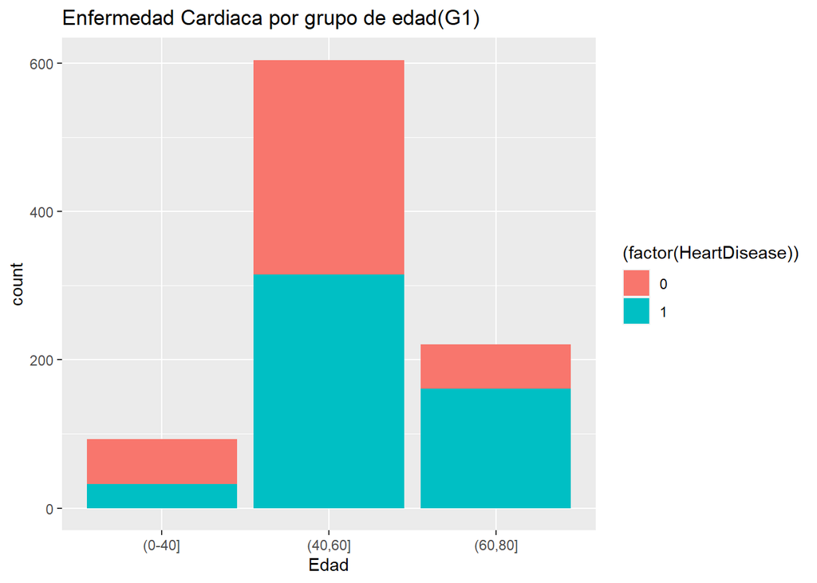

```r
library(ggplot2)
ggplot(data=heart,aes(x=Age_dist,fill=(factor(HeartDisease))))+geom_bar() + ggtitle("Enfermedad Cardiaca por grupo de edad(G1)") + labs(x="Edad", colour= "HeartDisease")
```

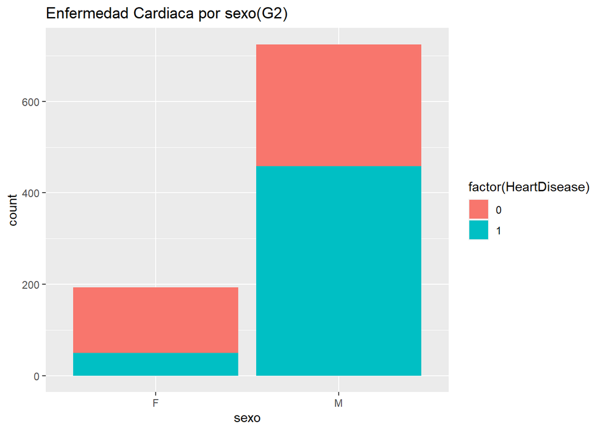

```r
ggplot(data=heart,aes(x=Sex,fill=factor(HeartDisease)))+geom_bar() + ggtitle("Enfermedad Cardiaca por sexo(G2)") + labs(x="sexo", colour= "HeartDisease")
```

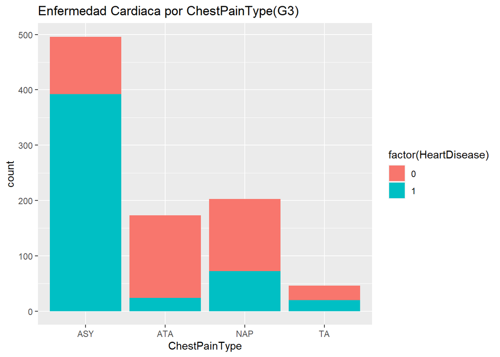

```r
ggplot(data=heart,aes(x=ChestPainType,fill=factor(HeartDisease)))+geom_bar() + ggtitle("Enfermedad Cardiaca por ChestPainType(G3)") + labs(x="ChestPainType", colour= "HeartDisease")
```

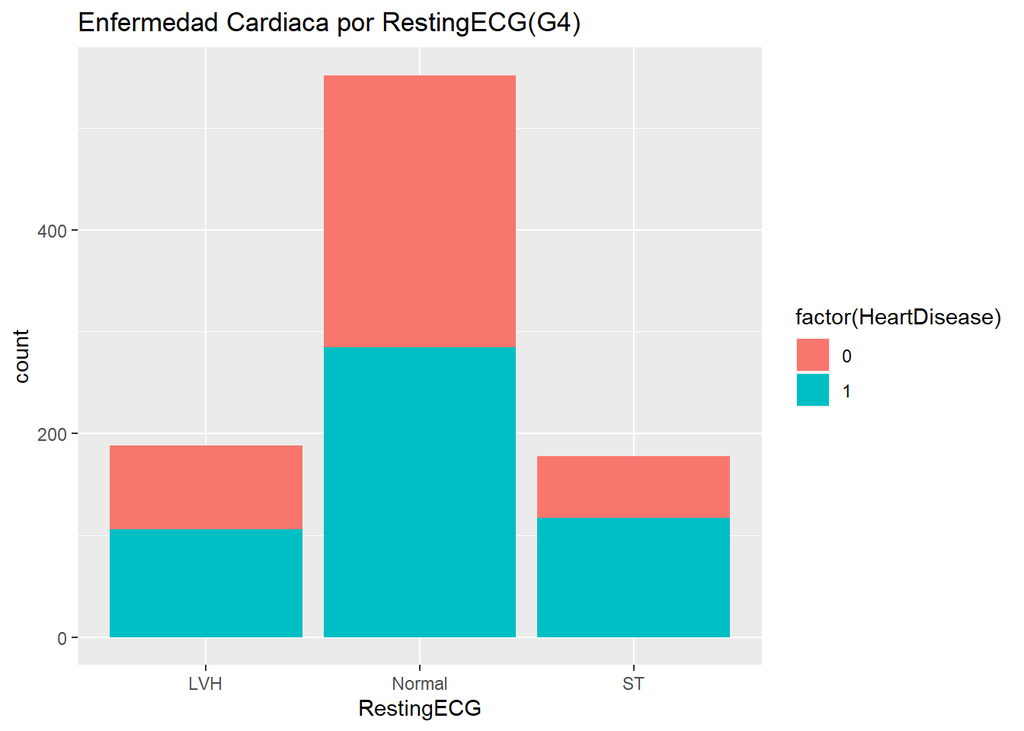

```r
ggplot(data=heart,aes(x=RestingECG,fill=factor(HeartDisease)))+geom_bar() + ggtitle("Enfermedad Cardiaca por RestingECG(G4)") + labs(x="RestingECG", colour= "HeartDisease")
```

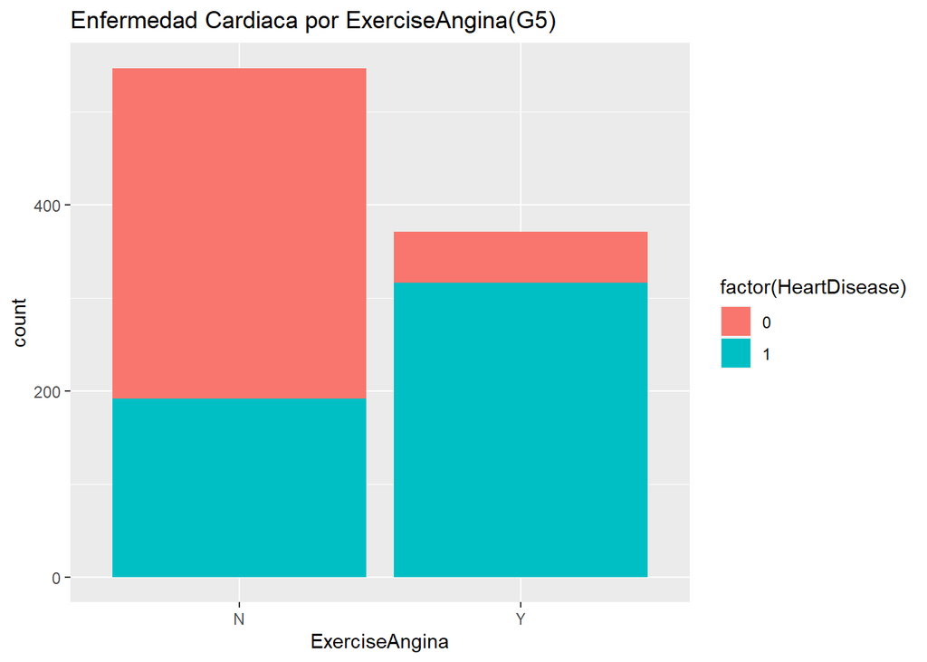

```r
# ExerciseAngina & HeartDisease
ggplot(data=heart,aes(x=ExerciseAngina,fill=factor(HeartDisease)))+geom_bar() + ggtitle("Enfermedad Cardiaca por ExerciseAngina(G5)") + labs(x="ExerciseAngina", colour= "HeartDisease")
```

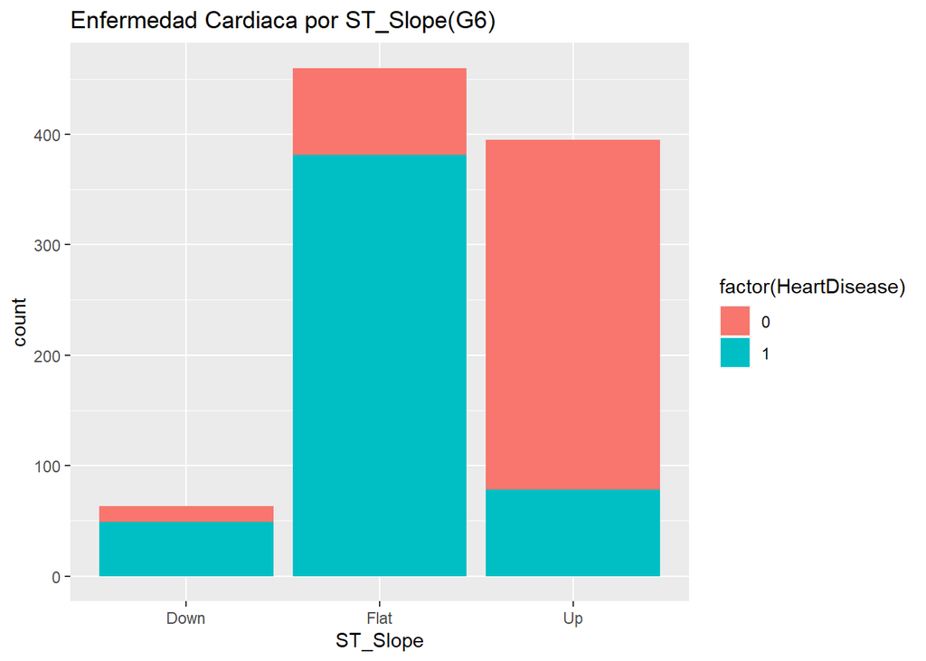

```r
# ST_Slope & HeartDisease
ggplot(data=heart,aes(x=ST_Slope,fill=factor(HeartDisease)))+geom_bar() + ggtitle("Enfermedad Cardiaca por ST_Slope(G6)") + labs(x="ST_Slope", colour= "HeartDisease")
```

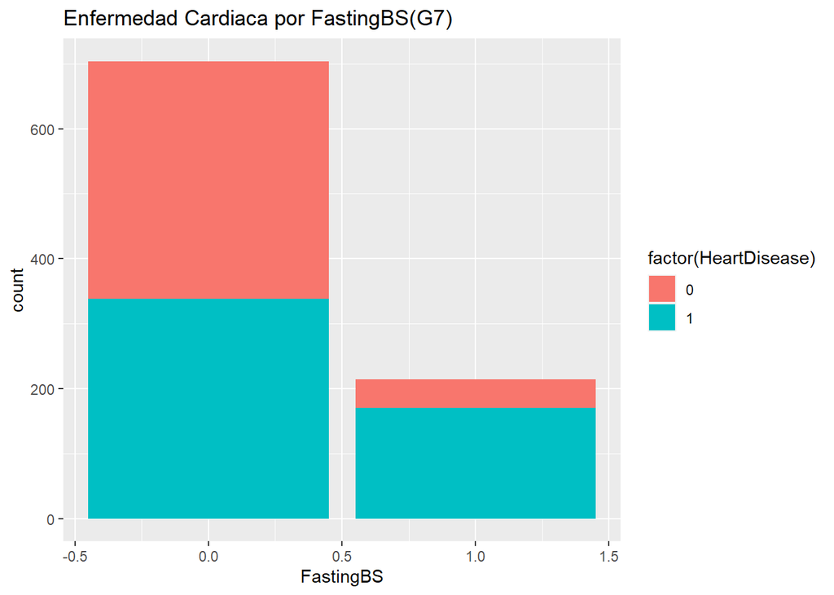

```r
# FastingBS & HeartDisease
ggplot(data=heart,aes(x=FastingBS,fill=factor(HeartDisease)))+geom_bar() + ggtitle("Enfermedad Cardiaca por FastingBS(G7)") + labs(x="FastingBS", colour= "HeartDisease")
```

Observando los gráficos anteriores podemos llevar a cabo las siguientes conclusiones:

G1: La edad influye en el riesgo o no de sufrir una enfermedad cardíaca, de 60 a 80 años el riesgo de sufrir una enfermedad cardíaca es mayor.

# 6 Conclusiones

# 7 Contribuciones

| **Contribuciones** | **Firma** |
| --- | --- |
| Investigación previa | Brais Santos, Jorge Álvarez Gracia |
| Redacción de las respuestas | Brais Santos, Jorge Álvarez Gracia |
| Desarrollo código | Brais Santos, Jorge Álvarez Gracia |

# 8 Recursos